# Project: Identify Customer Segments

In this project, you will apply unsupervised learning techniques to identify segments of the population that form the core customer base for a mail-order sales company in Germany. These segments can then be used to direct marketing campaigns towards audiences that will have the highest expected rate of returns. The data that you will use has been provided by our partners at Bertelsmann Arvato Analytics, and represents a real-life data science task.

This notebook will help you complete this task by providing a framework within which you will perform your analysis steps. In each step of the project, you will see some text describing the subtask that you will perform, followed by one or more code cells for you to complete your work. **Feel free to add additional code and markdown cells as you go along so that you can explore everything in precise chunks.** The code cells provided in the base template will outline only the major tasks, and will usually not be enough to cover all of the minor tasks that comprise it.

It should be noted that while there will be precise guidelines on how you should handle certain tasks in the project, there will also be places where an exact specification is not provided. **There will be times in the project where you will need to make and justify your own decisions on how to treat the data.** These are places where there may not be only one way to handle the data. In real-life tasks, there may be many valid ways to approach an analysis task. One of the most important things you can do is clearly document your approach so that other scientists can understand the decisions you've made.

At the end of most sections, there will be a Markdown cell labeled **Discussion**. In these cells, you will report your findings for the completed section, as well as document the decisions that you made in your approach to each subtask. **Your project will be evaluated not just on the code used to complete the tasks outlined, but also your communication about your observations and conclusions at each stage.**

**IMPORTANT NOTES**:

I decided to split the project notebook in two:

1. Assessment and Preprocessing
2. Applying PCA and KMeans

I did this so that I could separate both parts of the project, mostly for organization and for keeping the notebooks at an acceptable length.

I also decided to implement ColumnTransformers, FunctionFunctionTransformers, a Custom Transformer and a Pipeline, using help from a lot of online resources and sklearn documentation.

```python
# import libraries here; add more as necessary
import numpy as np
import pandas as pd
import matplotlib.pyplot as plt
import seaborn as sns

from sklearn.preprocessing import (OneHotEncoder, FunctionTransformer, StandardScaler)
from sklearn.compose import ColumnTransformer
from sklearn.impute import SimpleImputer
from sklearn.pipeline import Pipeline
from sklearn.base import BaseEstimator, TransformerMixin
from sklearn import set_config

from pprint import pprint
import json
import gc

import random
import copy
from joblib import dump

from IPython.display import display, HTML

# magic word for producing visualizations in notebook
%matplotlib inline

pd.options.display.max_rows = None
pd.options.display.max_columns = None
random.seed(42)

# So that our sklearn estimators/transformers output a pandas dataframe
set_config(transform_output="pandas")
```

Here I define constants that I will use, that way I avoid hard-coding strings:

```python
# CONSTANTS
# Feature Types
BINARY = "binary"
NOMINAL_BINARY = "nominal_binary"
NUMERIC = "numeric"
ORDINAL = "ordinal"
INTERVAL = "interval"
CATEGORICAL = "categorical" # General Term
MULTI_CAT = "multi_level_categorical" # More than 2 unique values
MIXED = "mixed" # Mixed Types

ENCODED_FEATURES = "encoded_features" # Features resulting from encoding (One-Hot Encode)

# For feature actions
TO_ENGINEER = "features_to_engineer"
TO_DROP = "features_to_drop"

# Re-encoded feature
OST_WEST = 'OST_WEST_KZ'

# Features to engineer
PRA_JUG = 'PRAEGENDE_JUGENDJAHRE'
CAM_INT = 'CAMEO_INTL_2015'

# Engineered (new) features
P_DECADE = 'PRAEGENDE_DECADE'
P_MOVEMENT = 'PRAEGENDE_MOVEMENT'

C_WEALTH = 'CAMEO_WEALTH'
C_LIFE = 'CAMEO_LIFESTAGE'

# Data filenames
DATA_AZDIAS = "Udacity_AZDIAS_Subset.csv"
DATA_CUSTOMERS = "Udacity_CUSTOMERS_Subset.csv"
DATA_F_SUMMARY = "AZDIAS_Feature_Summary.csv"
DATA_DICT = "data_dictionary.json"

# FEATURE SUMMARY COLUMN LABELS
FS_TYPE = "type"
FS_ATTR = "attribute"
FS_OBJ = "object"
FS_MISS_UNKWN = "missing_or_unknown"

# FEATURES REMOVED BY COLUMN THRESHOLD
NA_FEATURES = "na_features" # Features to be dropped by high NaN % per feature, and later from the customers data
ORIG_FEATURES = "original_features" # original features to be dropped after OHE

# FOR SAVING FILES
POPULATION_DATA_CLEAN = "population_data.csv" # Preprocessed, clean and scaled population demographics data
CUSTOMER_DATA_CLEAN = "customer_data.csv" # Preprocessed, clean and scaled customer data
SCALER = "scaler.pkl" # Saving the scaler state so that we can use it for inverse transform after clustering
```

And here I am definining 'global' variables that I will use throught the notebook:

```python
# GENERAL VARIABLES TO BE USED THROUGHOUT THE NOTEBOOK
# For keeping track of the expected number of features (for sanity check later)
expected_n_features = 0

# For organizing features into groups to guide the preprocessing pipeline
# Keeping it organized allows me to apply the same steps to the customer data

# Initialized
feature_groups = {
    # Feature types
    BINARY: set(),
    NOMINAL_BINARY: set(),
    ORDINAL: set(),
    NUMERIC: set(),
    INTERVAL: set(),
    MULTI_CAT: set(),
    ENCODED_FEATURES: set(),
    # Keep track of mixed-features to engineer
    TO_ENGINEER: set(),
    # Keep track of features to drop
    TO_DROP: {
        CATEGORICAL: set(),
        NA_FEATURES: set(),
        MIXED: set(),
    }
}

# For organizing mappings
# Create a dict for each original feature
mappings = {
    PRA_JUG: {},
    CAM_INT: {},
}

# For the feature dictionary
feature_dictionary = {}
```

### Step 0: Load the Data

Each row of the demographics files represents a single person, but also includes information outside of individuals, including information about their household, building, and neighborhood. You will use this information to cluster the general population into groups with similar demographic properties. Then, you will see how the people in the customers dataset fit into those created clusters. The hope here is that certain clusters are over-represented in the customers data, as compared to the general population; those over-represented clusters will be assumed to be part of the core userbase. This information can then be used for further applications, such as targeting for a marketing campaign.

To start off with, load in the demographics data for the general population into a pandas DataFrame, and do the same for the feature attributes summary. Note for all of the `.csv` data files in this project: they're semicolon (`;`) delimited, so you'll need an additional argument in your [`read_csv()`](https://pandas.pydata.org/pandas-docs/stable/generated/pandas.read_csv.html) call to read in the data properly. Also, considering the size of the main dataset, it may take some time for it to load completely.

Once the dataset is loaded, it's recommended that you take a little bit of time just browsing the general structure of the dataset and feature summary file. You'll be getting deep into the innards of the cleaning in the first major step of the project, so gaining some general familiarity can help you get your bearings.

```python
# Load in the general demographics data.
df_population_raw = pd.read_csv(DATA_AZDIAS, delimiter=';')

# Load in the feature summary file.
feature_summary = pd.read_csv(DATA_F_SUMMARY, delimiter=';')
```

#### Step 0.1.1: General Population Data:

```python
# Check the structure of the data after it's loaded (e.g. print the number of
# rows and columns, print the first few rows).
population_rows, population_cols = df_population_raw.shape
print(f"Population rows: {population_rows}")
print(f"Population columns: {population_cols}")

# As we start with 85 columns, we update the expected number of features
expected_n_features = population_cols
```

```
Population rows: 891221
Population columns: 85
```

```python
# Info
df_population_raw.info()
```

```
<class 'pandas.core.frame.DataFrame'>
RangeIndex: 891221 entries, 0 to 891220
Data columns (total 85 columns):
 #   Column                 Non-Null Count   Dtype
---  ------                 --------------   -----
 0   AGER_TYP               891221 non-null  int64
 1   ALTERSKATEGORIE_GROB   891221 non-null  int64
 2   ANREDE_KZ              891221 non-null  int64
 3   CJT_GESAMTTYP          886367 non-null  float64
 4   FINANZ_MINIMALIST      891221 non-null  int64
 5   FINANZ_SPARER          891221 non-null  int64
 6   FINANZ_VORSORGER       891221 non-null  int64
 7   FINANZ_ANLEGER         891221 non-null  int64
 8   FINANZ_UNAUFFAELLIGER  891221 non-null  int64
 9   FINANZ_HAUSBAUER       891221 non-null  int64
```

[output cut: 77 more lines]

```python
# View some rows
df_population_raw.head()
```

|  | AGER_TYP | ALTERSKATEGORIE_GROB | ANREDE_KZ | CJT_GESAMTTYP | FINANZ_MINIMALIST | FINANZ_SPARER | FINANZ_VORSORGER | FINANZ_ANLEGER | FINANZ_UNAUFFAELLIGER | FINANZ_HAUSBAUER | FINANZTYP | GEBURTSJAHR | GFK_URLAUBERTYP | GREEN_AVANTGARDE | HEALTH_TYP | LP_LEBENSPHASE_FEIN | LP_LEBENSPHASE_GROB | LP_FAMILIE_FEIN | LP_FAMILIE_GROB | LP_STATUS_FEIN | LP_STATUS_GROB | NATIONALITAET_KZ | PRAEGENDE_JUGENDJAHRE | RETOURTYP_BK_S | SEMIO_SOZ | SEMIO_FAM | SEMIO_REL | SEMIO_MAT | SEMIO_VERT | … |
| --- | --- | --- | --- | --- | --- | --- | --- | --- | --- | --- | --- | --- | --- | --- | --- | --- | --- | --- | --- | --- | --- | --- | --- | --- | --- | --- | --- | --- | --- | --- |
| 0 | -1 | 2 | 1 | 2.0 | 3 | 4 | 3 | 5 | 5 | 3 | 4 | 0 | 10.0 | 0 | -1 | 15.0 | 4.0 | 2.0 | 2.0 | 1.0 | 1.0 | 0 | 0 | 5.0 | 2 | 6 | 7 | 5 | 1 | … |
| 1 | -1 | 1 | 2 | 5.0 | 1 | 5 | 2 | 5 | 4 | 5 | 1 | 1996 | 10.0 | 0 | 3 | 21.0 | 6.0 | 5.0 | 3.0 | 2.0 | 1.0 | 1 | 14 | 1.0 | 5 | 4 | 4 | 3 | 1 | … |
| 2 | -1 | 3 | 2 | 3.0 | 1 | 4 | 1 | 2 | 3 | 5 | 1 | 1979 | 10.0 | 1 | 3 | 3.0 | 1.0 | 1.0 | 1.0 | 3.0 | 2.0 | 1 | 15 | 3.0 | 4 | 1 | 3 | 3 | 4 | … |
| 3 | 2 | 4 | 2 | 2.0 | 4 | 2 | 5 | 2 | 1 | 2 | 6 | 1957 | 1.0 | 0 | 2 | 0.0 | 0.0 | 0.0 | 0.0 | 9.0 | 4.0 | 1 | 8 | 2.0 | 5 | 1 | 2 | 1 | 4 | … |
| 4 | -1 | 3 | 1 | 5.0 | 4 | 3 | 4 | 1 | 3 | 2 | 5 | 1963 | 5.0 | 0 | 3 | 32.0 | 10.0 | 10.0 | 5.0 | 3.0 | 2.0 | 1 | 8 | 5.0 | 6 | 4 | 4 | 2 | 7 | … |

```python
# data types
df_population_raw.dtypes.value_counts()
```

```
float64    49
int64      32
object      4
Name: count, dtype: int64
```

So basic information about the general population demographics data:

- There are 891,221 entries/samples, or rows, each representing one person
- There are a total of 85 rows or features
- There are 81 numeric features (32xint64 + 49xfloat64) and 4 non-numeric features (objects)

#### Step 0.1.2: Feature Summary

```python
# Show some rows
feature_summary.head()
```

|  | attribute | information_level | type | missing_or_unknown |
| --- | --- | --- | --- | --- |
| 0 | AGER_TYP | person | categorical | [-1,0] |
| 1 | ALTERSKATEGORIE_GROB | person | ordinal | [-1,0,9] |
| 2 | ANREDE_KZ | person | categorical | [-1,0] |
| 3 | CJT_GESAMTTYP | person | categorical | [0] |
| 4 | FINANZ_MINIMALIST | person | ordinal | [-1] |

```python
# Info
feature_summary.info()
```

```
<class 'pandas.core.frame.DataFrame'>
RangeIndex: 85 entries, 0 to 84
Data columns (total 4 columns):
 #   Column              Non-Null Count  Dtype
---  ------              --------------  -----
 0   attribute           85 non-null     object
 1   information_level   85 non-null     object
 2   type                85 non-null     object
 3   missing_or_unknown  85 non-null     object
dtypes: object(4)
memory usage: 2.8+ KB
```

```python
# Explore the 'type' column. Get the counts
feature_summary['type'].value_counts()
```

```
type
ordinal        49
categorical    21
numeric         7
mixed           7
interval        1
Name: count, dtype: int64
```

The feature summary basically gives us the following information about each attribute/column/feature:

- attribute: the name of the attribute/feature
- information_level: attributes can be personal or higher-level (ex. geographical)
- type: the kind of data that an attribute or feature contains: orinal (ranked), categorical (labels/codes), numeric (numbers), mixed or interval
- missing_or_unknown: values for missing or unknown attribute data

#### Step 0.1.3: Loading the Data Dictionary:

I decided to load the Data Dictionary from a JSON file I created so that I can reference it in this notebook.

```python
# Load the Data Dictionary
with open(DATA_DICT, 'r') as f:
    feature_dictionary = json.load(f)

pprint(feature_dictionary, depth=1)
```

```
{'AGER_TYP': {...},
 'ALTERSKATEGORIE_GROB': {...},
 'ALTER_HH': {...},
 'ANREDE_KZ': {...},
 'ANZ_HAUSHALTE_AKTIV': {...},
 'ANZ_HH_TITEL': {...},
 'ANZ_PERSONEN': {...},
 'ANZ_TITEL': {...},
 'ARBEIT': {...},
 'BALLRAUM': {...},
 'CAMEO_DEUG_2015': {...},
 'CAMEO_DEU_2015': {...},
 'CAMEO_INTL_2015': {...},
 'CJT_GESAMTTYP': {...},
 'EWDICHTE': {...},
 'FINANZTYP': {...},
 'FINANZ_ANLEGER': {...},
 'FINANZ_HAUSBAUER': {...},
 'FINANZ_MINIMALIST': {...},
 'FINANZ_SPARER': {...},
 'FINANZ_UNAUFFAELLIGER': {...},
 'FINANZ_VORSORGER': {...},
 'GEBAEUDETYP': {...},
 'GEBAEUDETYP_RASTER': {...},
 'GEBURTSJAHR': {...},
 'GFK_URLAUBERTYP': {...},
 'GREEN_AVANTGARDE': {...},
 'HEALTH_TYP': {...},
 'HH_EINKOMMEN_SCORE': {...},
 'INNENSTADT': {...},
 'KBA05_ANTG1': {...},
 'KBA05_ANTG2': {...},
 'KBA05_ANTG3': {...},
 'KBA05_ANTG4': {...},
 'KBA05_BAUMAX': {...},
 'KBA05_GBZ': {...},
 'KBA13_ANZAHL_PKW': {...},
 'KKK': {...},
 'KK_KUNDENTYP': {...},
 'KONSUMNAEHE': {...},
```

[output cut: 30 more lines]

```
 'SEMIO_MAT': {...},
 'SEMIO_PFLICHT': {...},
 'SEMIO_RAT': {...},
 'SEMIO_REL': {...},
 'SEMIO_SOZ': {...},
 'SEMIO_TRADV': {...},
 'SEMIO_VERT': {...},
 'SHOPPER_TYP': {...},
 'SOHO_KZ': {...},
 'TITEL_KZ': {...},
 'VERS_TYP': {...},
 'WOHNDAUER_2008': {...},
 'WOHNLAGE': {...},
 'W_KEIT_KIND_HH': {...},
 'ZABEOTYP': {...}}
```

## Step 1: Preprocessing

### Step 1.1: Assess Missing Data

The feature summary file contains a summary of properties for each demographics data column. You will use this file to help you make cleaning decisions during this stage of the project. First of all, you should assess the demographics data in terms of missing data. Pay attention to the following points as you perform your analysis, and take notes on what you observe. Make sure that you fill in the **Discussion** cell with your findings and decisions at the end of each step that has one!

#### Step 1.1.1: Convert Missing Value Codes to NaNs

The fourth column of the feature attributes summary (loaded in above as `feat_info`) documents the codes from the data dictionary that indicate missing or unknown data. While the file encodes this as a list (e.g. `[-1,0]`), this will get read in as a string object. You'll need to do a little bit of parsing to make use of it to identify and clean the data. Convert data that matches a 'missing' or 'unknown' value code into a numpy NaN value. You might want to see how much data takes on a 'missing' or 'unknown' code, and how much data is naturally missing, as a point of interest.

**As one more reminder, you are encouraged to add additional cells to break up your analysis into manageable chunks.**

```python
# Asses how many NaN values are in the data
na_total = df_population_raw.isna().sum().sum()
print(f"Total NaN Values Currently in Population Data: {na_total:,}")
```

```
Total NaN Values Currently in Population Data: 4,896,838
```

```python
# Asses per feature
df_population_raw.isna().sum().sort_values(ascending=False)
```

```
KK_KUNDENTYP             584612
KBA05_GBZ                133324
KBA05_ANTG1              133324
KBA05_ANTG3              133324
MOBI_REGIO               133324
KBA05_ANTG2              133324
KBA05_ANTG4              133324
KBA05_BAUMAX             133324
REGIOTYP                 121196
KKK                      121196
PLZ8_HHZ                 116515
PLZ8_BAUMAX              116515
PLZ8_ANTG4               116515
PLZ8_GBZ                 116515
PLZ8_ANTG2               116515
PLZ8_ANTG1               116515
PLZ8_ANTG3               116515
W_KEIT_KIND_HH           107602
KBA13_ANZAHL_PKW         105800
CAMEO_INTL_2015           98979
CAMEO_DEU_2015            98979
CAMEO_DEUG_2015           98979
ARBEIT                    97216
ORTSGR_KLS9               97216
RELAT_AB                  97216
ANZ_HH_TITEL              97008
BALLRAUM                  93740
INNENSTADT                93740
EWDICHTE                  93740
GEBAEUDETYP_RASTER        93155
WOHNLAGE                  93148
ANZ_HAUSHALTE_AKTIV       93148
MIN_GEBAEUDEJAHR          93148
OST_WEST_KZ               93148
GEBAEUDETYP               93148
KONSUMNAEHE               73969
ANZ_PERSONEN              73499
WOHNDAUER_2008            73499
ANZ_TITEL                 73499
ALTER_HH                  73499
```

[output cut: 31 more lines]

```
SEMIO_REL                     0
SEMIO_MAT                     0
SEMIO_VERT                    0
SEMIO_LUST                    0
SEMIO_ERL                     0
SEMIO_KULT                    0
SEMIO_RAT                     0
SEMIO_KRIT                    0
SEMIO_DOM                     0
SEMIO_KAEM                    0
SEMIO_PFLICHT                 0
SEMIO_TRADV                   0
SHOPPER_TYP                   0
ZABEOTYP                      0
dtype: int64
```

#### Step 1.1.1.1: Identifying Missing Data:

```python
# Fourth column in feature summary documents the codes that indicate missing or unknown data. These will be read as string objects
# Iterate over each attribute and missing or unknown codes list
for attribute, missing_encoded_str in zip(feature_summary['attribute'], feature_summary['missing_or_unknown']):
    print(f"Feature {attribute} encodes missing values as: {missing_encoded_str}, {type(missing_encoded_str)}")
```

```
Feature AGER_TYP encodes missing values as: [-1,0], <class 'str'>
Feature ALTERSKATEGORIE_GROB encodes missing values as: [-1,0,9], <class 'str'>
Feature ANREDE_KZ encodes missing values as: [-1,0], <class 'str'>
Feature CJT_GESAMTTYP encodes missing values as: [0], <class 'str'>
Feature FINANZ_MINIMALIST encodes missing values as: [-1], <class 'str'>
Feature FINANZ_SPARER encodes missing values as: [-1], <class 'str'>
Feature FINANZ_VORSORGER encodes missing values as: [-1], <class 'str'>
Feature FINANZ_ANLEGER encodes missing values as: [-1], <class 'str'>
Feature FINANZ_UNAUFFAELLIGER encodes missing values as: [-1], <class 'str'>
Feature FINANZ_HAUSBAUER encodes missing values as: [-1], <class 'str'>
Feature FINANZTYP encodes missing values as: [-1], <class 'str'>
Feature GEBURTSJAHR encodes missing values as: [0], <class 'str'>
Feature GFK_URLAUBERTYP encodes missing values as: [], <class 'str'>
Feature GREEN_AVANTGARDE encodes missing values as: [], <class 'str'>
Feature HEALTH_TYP encodes missing values as: [-1,0], <class 'str'>
Feature LP_LEBENSPHASE_FEIN encodes missing values as: [0], <class 'str'>
Feature LP_LEBENSPHASE_GROB encodes missing values as: [0], <class 'str'>
Feature LP_FAMILIE_FEIN encodes missing values as: [0], <class 'str'>
Feature LP_FAMILIE_GROB encodes missing values as: [0], <class 'str'>
Feature LP_STATUS_FEIN encodes missing values as: [0], <class 'str'>
Feature LP_STATUS_GROB encodes missing values as: [0], <class 'str'>
Feature NATIONALITAET_KZ encodes missing values as: [-1,0], <class 'str'>
Feature PRAEGENDE_JUGENDJAHRE encodes missing values as: [-1,0], <class 'str'>
Feature RETOURTYP_BK_S encodes missing values as: [0], <class 'str'>
Feature SEMIO_SOZ encodes missing values as: [-1,9], <class 'str'>
Feature SEMIO_FAM encodes missing values as: [-1,9], <class 'str'>
Feature SEMIO_REL encodes missing values as: [-1,9], <class 'str'>
Feature SEMIO_MAT encodes missing values as: [-1,9], <class 'str'>
Feature SEMIO_VERT encodes missing values as: [-1,9], <class 'str'>
Feature SEMIO_LUST encodes missing values as: [-1,9], <class 'str'>
Feature SEMIO_ERL encodes missing values as: [-1,9], <class 'str'>
Feature SEMIO_KULT encodes missing values as: [-1,9], <class 'str'>
Feature SEMIO_RAT encodes missing values as: [-1,9], <class 'str'>
Feature SEMIO_KRIT encodes missing values as: [-1,9], <class 'str'>
Feature SEMIO_DOM encodes missing values as: [-1,9], <class 'str'>
Feature SEMIO_KAEM encodes missing values as: [-1,9], <class 'str'>
Feature SEMIO_PFLICHT encodes missing values as: [-1,9], <class 'str'>
Feature SEMIO_TRADV encodes missing values as: [-1,9], <class 'str'>
Feature SHOPPER_TYP encodes missing values as: [-1], <class 'str'>
Feature SOHO_KZ encodes missing values as: [-1], <class 'str'>
```

[output cut: 30 more lines]

```
Feature KKK encodes missing values as: [-1,0], <class 'str'>
Feature MOBI_REGIO encodes missing values as: [], <class 'str'>
Feature ONLINE_AFFINITAET encodes missing values as: [], <class 'str'>
Feature REGIOTYP encodes missing values as: [-1,0], <class 'str'>
Feature KBA13_ANZAHL_PKW encodes missing values as: [], <class 'str'>
Feature PLZ8_ANTG1 encodes missing values as: [-1], <class 'str'>
Feature PLZ8_ANTG2 encodes missing values as: [-1], <class 'str'>
Feature PLZ8_ANTG3 encodes missing values as: [-1], <class 'str'>
Feature PLZ8_ANTG4 encodes missing values as: [-1], <class 'str'>
Feature PLZ8_BAUMAX encodes missing values as: [-1,0], <class 'str'>
Feature PLZ8_HHZ encodes missing values as: [-1], <class 'str'>
Feature PLZ8_GBZ encodes missing values as: [-1], <class 'str'>
Feature ARBEIT encodes missing values as: [-1,9], <class 'str'>
Feature ORTSGR_KLS9 encodes missing values as: [-1,0], <class 'str'>
Feature RELAT_AB encodes missing values as: [-1,9], <class 'str'>
```

Convert missing_or_unknown strings into actual lists of values:

```python
# Define a function to do this:
def get_missing_summary(fs):
    """
    Function that returns a dictionary mapping each attribute in a feature summary
    To a list of the missing or unknown codes for that attribute
    :param fs: Feature summary
    :return: Dictionary mapping attribute to a list of missing or unknown codes
    """

    def get_numeric_value(s):
        """
        Basic function that attempts to cast a string into an int.
        :param s: the string to cast to int
        :return: the integer represented by the string or the original string if invalid string
        """
        try:
            return int(s)
        except ValueError:
            return s

    # Init dictionary
    missing_summary = {}

    # iterate over attributes (to use as key) and missing_or_unknown values (as strings now)
    for attribute, missing_code_str in zip(fs[FS_ATTR], fs[FS_MISS_UNKWN]):

        # clean up the string and create a list
        temp_list = list(missing_code_str.replace(" ", "").replace("[","").replace("]","").split(","))

        # check that the list is not empty
        if len(temp_list) > 0 and temp_list[0] != "":
            # convert strings into numerical values
            missing_summary[attribute] = [get_numeric_value(s) for s in temp_list]

    return missing_summary

pprint(f"miss_or_unkwn dictionary: {get_missing_summary(feature_summary)}")
```

```
("miss_or_unkwn dictionary: {'AGER_TYP': [-1, 0], 'ALTERSKATEGORIE_GROB': [-1, "
 "0, 9], 'ANREDE_KZ': [-1, 0], 'CJT_GESAMTTYP': [0], 'FINANZ_MINIMALIST': "
 "[-1], 'FINANZ_SPARER': [-1], 'FINANZ_VORSORGER': [-1], 'FINANZ_ANLEGER': "
 "[-1], 'FINANZ_UNAUFFAELLIGER': [-1], 'FINANZ_HAUSBAUER': [-1], 'FINANZTYP': "
 "[-1], 'GEBURTSJAHR': [0], 'HEALTH_TYP': [-1, 0], 'LP_LEBENSPHASE_FEIN': [0], "
 "'LP_LEBENSPHASE_GROB': [0], 'LP_FAMILIE_FEIN': [0], 'LP_FAMILIE_GROB': [0], "
 "'LP_STATUS_FEIN': [0], 'LP_STATUS_GROB': [0], 'NATIONALITAET_KZ': [-1, 0], "
 "'PRAEGENDE_JUGENDJAHRE': [-1, 0], 'RETOURTYP_BK_S': [0], 'SEMIO_SOZ': [-1, "
 "9], 'SEMIO_FAM': [-1, 9], 'SEMIO_REL': [-1, 9], 'SEMIO_MAT': [-1, 9], "
 "'SEMIO_VERT': [-1, 9], 'SEMIO_LUST': [-1, 9], 'SEMIO_ERL': [-1, 9], "
 "'SEMIO_KULT': [-1, 9], 'SEMIO_RAT': [-1, 9], 'SEMIO_KRIT': [-1, 9], "
 "'SEMIO_DOM': [-1, 9], 'SEMIO_KAEM': [-1, 9], 'SEMIO_PFLICHT': [-1, 9], "
 "'SEMIO_TRADV': [-1, 9], 'SHOPPER_TYP': [-1], 'SOHO_KZ': [-1], 'TITEL_KZ': "
 "[-1, 0], 'VERS_TYP': [-1], 'ZABEOTYP': [-1, 9], 'ALTER_HH': [0], "
 "'HH_EINKOMMEN_SCORE': [-1, 0], 'KK_KUNDENTYP': [-1], 'W_KEIT_KIND_HH': [-1, "
 "0], 'WOHNDAUER_2008': [-1, 0], 'ANZ_HAUSHALTE_AKTIV': [0], 'GEBAEUDETYP': "
 "[-1, 0], 'MIN_GEBAEUDEJAHR': [0], 'OST_WEST_KZ': [-1], 'WOHNLAGE': [-1], "
 "'CAMEO_DEUG_2015': [-1, 'X'], 'CAMEO_DEU_2015': ['XX'], 'CAMEO_INTL_2015': "
 "[-1, 'XX'], 'KBA05_ANTG1': [-1], 'KBA05_ANTG2': [-1], 'KBA05_ANTG3': [-1], "
 "'KBA05_ANTG4': [-1], 'KBA05_BAUMAX': [-1, 0], 'KBA05_GBZ': [-1, 0], "
 "'BALLRAUM': [-1], 'EWDICHTE': [-1], 'INNENSTADT': [-1], 'KKK': [-1, 0], "
 "'REGIOTYP': [-1, 0], 'PLZ8_ANTG1': [-1], 'PLZ8_ANTG2': [-1], 'PLZ8_ANTG3': "
 "[-1], 'PLZ8_ANTG4': [-1], 'PLZ8_BAUMAX': [-1, 0], 'PLZ8_HHZ': [-1], "
 "'PLZ8_GBZ': [-1], 'ARBEIT': [-1, 9], 'ORTSGR_KLS9': [-1, 0], 'RELAT_AB': "
 '[-1, 9]}')
```

Now we go over all the columns having missing or unknown values and replace them with NaN:

```python
def replace_missing(df, fs, return_count=False, verbose=False):
    """
    Replaces missing or unknown coded values in DataFrame with NaN
    :param df: Target DataFrame
    :param fs: Feature Summary
    :param return_count: flag for if we want to return the count of replaced values
    :param verbose: flag for if we want to print more information
    :return: tuple(converted DataFrame, count of replaced values)
    or just the converted DataFrame, depending on return_count flag
    """
    # Make a copy
    df = df.copy()

    # Get the missing summary dictionary
    missing_summary = get_missing_summary(fs)

    # keep track of total missing or unknown datums (so we can have a separate value for real NaN values in the data
    # and converted NaN values). Used later for sanity check.
    converted_na_total = 0

    # we iterate over each attribute and list pair in the dictionary
    # we don't iterate over each column, as not all of them have missing_or_unknown codes
    for attribute, lst in missing_summary.items():

        # Skip over any attribute that is not in the DataFrame
        if attribute not in df:
            continue

        # Get the sum of missing or unknown values for that attribute/feature in the general pop. data
        # We use isin() function to match with the list of missing_or_unknown values and then sum them up
        n_miss = df[attribute].isin(lst).sum()

        # Get the count of real NaN values in the dataset for that feature
        n_nan = df[attribute].isna().sum()

        if verbose:
            print(f"{attribute} has {n_miss} missing or unknowns and {n_nan} real NaN values.")

        # Replace all the values with NaN
        df[attribute] = df[attribute].replace(lst, np.nan)

        # increment total
        converted_na_total += n_miss

    return (df, converted_na_total) if return_count else df
```

```python
# Replace missing or unknowns with NaN
df_population, converted_na_total = replace_missing(df_population_raw, feature_summary, return_count=True, verbose=True)
print()
print(f"Total number of missing values: {converted_na_total:,}")
```

```
AGER_TYP has 685843 missing or unknowns and 0 real NaN values.
ALTERSKATEGORIE_GROB has 2881 missing or unknowns and 0 real NaN values.
ANREDE_KZ has 0 missing or unknowns and 0 real NaN values.
CJT_GESAMTTYP has 0 missing or unknowns and 4854 real NaN values.
FINANZ_MINIMALIST has 0 missing or unknowns and 0 real NaN values.
FINANZ_SPARER has 0 missing or unknowns and 0 real NaN values.
FINANZ_VORSORGER has 0 missing or unknowns and 0 real NaN values.
FINANZ_ANLEGER has 0 missing or unknowns and 0 real NaN values.
FINANZ_UNAUFFAELLIGER has 0 missing or unknowns and 0 real NaN values.
FINANZ_HAUSBAUER has 0 missing or unknowns and 0 real NaN values.
FINANZTYP has 0 missing or unknowns and 0 real NaN values.
GEBURTSJAHR has 392318 missing or unknowns and 0 real NaN values.
HEALTH_TYP has 111196 missing or unknowns and 0 real NaN values.
LP_LEBENSPHASE_FEIN has 92778 missing or unknowns and 4854 real NaN values.
LP_LEBENSPHASE_GROB has 89718 missing or unknowns and 4854 real NaN values.
LP_FAMILIE_FEIN has 72938 missing or unknowns and 4854 real NaN values.
LP_FAMILIE_GROB has 72938 missing or unknowns and 4854 real NaN values.
LP_STATUS_FEIN has 0 missing or unknowns and 4854 real NaN values.
LP_STATUS_GROB has 0 missing or unknowns and 4854 real NaN values.
NATIONALITAET_KZ has 108315 missing or unknowns and 0 real NaN values.
PRAEGENDE_JUGENDJAHRE has 108164 missing or unknowns and 0 real NaN values.
RETOURTYP_BK_S has 0 missing or unknowns and 4854 real NaN values.
SEMIO_SOZ has 0 missing or unknowns and 0 real NaN values.
SEMIO_FAM has 0 missing or unknowns and 0 real NaN values.
SEMIO_REL has 0 missing or unknowns and 0 real NaN values.
SEMIO_MAT has 0 missing or unknowns and 0 real NaN values.
SEMIO_VERT has 0 missing or unknowns and 0 real NaN values.
SEMIO_LUST has 0 missing or unknowns and 0 real NaN values.
SEMIO_ERL has 0 missing or unknowns and 0 real NaN values.
SEMIO_KULT has 0 missing or unknowns and 0 real NaN values.
SEMIO_RAT has 0 missing or unknowns and 0 real NaN values.
SEMIO_KRIT has 0 missing or unknowns and 0 real NaN values.
SEMIO_DOM has 0 missing or unknowns and 0 real NaN values.
SEMIO_KAEM has 0 missing or unknowns and 0 real NaN values.
SEMIO_PFLICHT has 0 missing or unknowns and 0 real NaN values.
SEMIO_TRADV has 0 missing or unknowns and 0 real NaN values.
SHOPPER_TYP has 111196 missing or unknowns and 0 real NaN values.
SOHO_KZ has 0 missing or unknowns and 73499 real NaN values.
TITEL_KZ has 815562 missing or unknowns and 73499 real NaN values.
VERS_TYP has 111196 missing or unknowns and 0 real NaN values.
```

[output cut: 22 more lines]

```
INNENSTADT has 0 missing or unknowns and 93740 real NaN values.
KKK has 36868 missing or unknowns and 121196 real NaN values.
REGIOTYP has 36868 missing or unknowns and 121196 real NaN values.
PLZ8_ANTG1 has 0 missing or unknowns and 116515 real NaN values.
PLZ8_ANTG2 has 0 missing or unknowns and 116515 real NaN values.
PLZ8_ANTG3 has 0 missing or unknowns and 116515 real NaN values.
PLZ8_ANTG4 has 0 missing or unknowns and 116515 real NaN values.
PLZ8_BAUMAX has 0 missing or unknowns and 116515 real NaN values.
PLZ8_HHZ has 0 missing or unknowns and 116515 real NaN values.
PLZ8_GBZ has 0 missing or unknowns and 116515 real NaN values.
ARBEIT has 159 missing or unknowns and 97216 real NaN values.
ORTSGR_KLS9 has 58 missing or unknowns and 97216 real NaN values.
RELAT_AB has 159 missing or unknowns and 97216 real NaN values.

Total number of missing values: 3,477,091
```

```python
# Now we can determine the total NaN values in the data
nan_total = converted_na_total + na_total
print(f"NaN Total: {nan_total:,}")
```

```
NaN Total: 8,373,929
```

```python
# And now we can delete the raw data to save memory
del df_population_raw
gc.collect()
```

```
12
```

#### Step 1.1.2: Assess Missing Data in Each Column

How much missing data is present in each column? There are a few columns that are outliers in terms of the proportion of values that are missing. You will want to use matplotlib's [`hist()`](https://matplotlib.org/api/_as_gen/matplotlib.pyplot.hist.html) function to visualize the distribution of missing value counts to find these columns. Identify and document these columns. While some of these columns might have justifications for keeping or re-encoding the data, for this project you should just remove them from the dataframe. (Feel free to make remarks about these outlier columns in the discussion, however!)

For the remaining features, are there any patterns in which columns have, or share, missing data?

```python
# Perform an assessment of how much missing data there is in each column of the
# dataset.
s_col_missing_counts = df_population.isna().sum()
s_missing_per_feature = s_col_missing_counts.sort_values(ascending=False)
s_missing_per_feature
```

```
TITEL_KZ                 889061
AGER_TYP                 685843
KK_KUNDENTYP             584612
KBA05_BAUMAX             476524
GEBURTSJAHR              392318
ALTER_HH                 310267
KKK                      158064
REGIOTYP                 158064
W_KEIT_KIND_HH           147988
KBA05_ANTG1              133324
KBA05_ANTG2              133324
KBA05_ANTG3              133324
KBA05_ANTG4              133324
KBA05_GBZ                133324
MOBI_REGIO               133324
PLZ8_ANTG3               116515
PLZ8_ANTG2               116515
PLZ8_GBZ                 116515
PLZ8_HHZ                 116515
PLZ8_ANTG1               116515
PLZ8_BAUMAX              116515
PLZ8_ANTG4               116515
VERS_TYP                 111196
HEALTH_TYP               111196
SHOPPER_TYP              111196
NATIONALITAET_KZ         108315
PRAEGENDE_JUGENDJAHRE    108164
KBA13_ANZAHL_PKW         105800
ANZ_HAUSHALTE_AKTIV       99611
CAMEO_INTL_2015           99352
CAMEO_DEU_2015            99352
CAMEO_DEUG_2015           99352
LP_LEBENSPHASE_FEIN       97632
ARBEIT                    97375
RELAT_AB                  97375
ORTSGR_KLS9               97274
ANZ_HH_TITEL              97008
LP_LEBENSPHASE_GROB       94572
INNENSTADT                93740
EWDICHTE                  93740
```

[output cut: 31 more lines]

```
SEMIO_SOZ                     0
SEMIO_PFLICHT                 0
SEMIO_FAM                     0
SEMIO_REL                     0
SEMIO_MAT                     0
SEMIO_VERT                    0
SEMIO_LUST                    0
SEMIO_ERL                     0
SEMIO_KULT                    0
SEMIO_RAT                     0
SEMIO_KRIT                    0
SEMIO_DOM                     0
SEMIO_TRADV                   0
ZABEOTYP                      0
dtype: int64
```

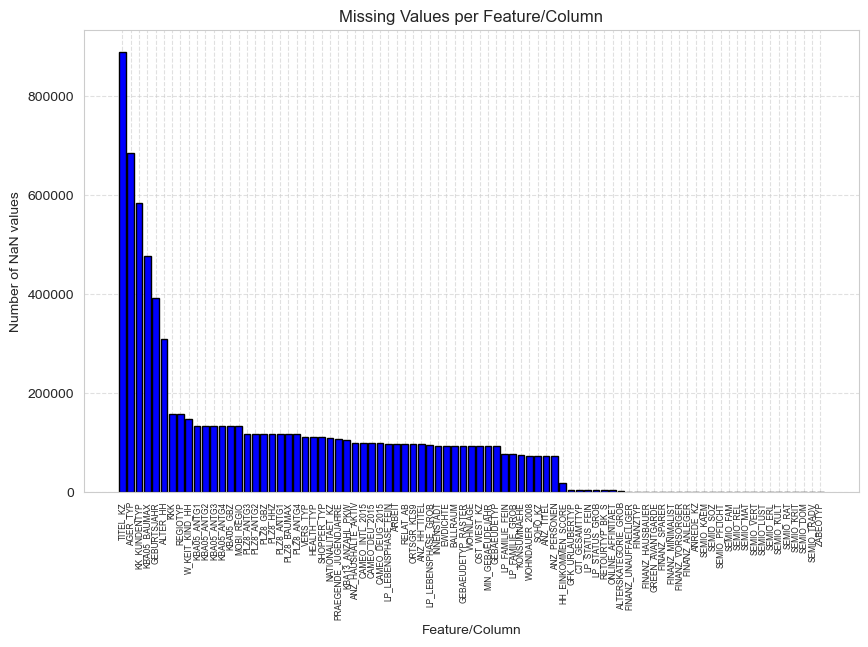

```python
# Plot Histogram (Using a Bar Chart)
plt.figure(figsize=(10,6))
plt.bar(s_missing_per_feature.index, s_missing_per_feature.values, color="b", edgecolor='black')
plt.title('Missing Values per Feature/Column')
plt.xlabel('Feature/Column')
plt.xticks(rotation=90, ha="center", fontsize=6)
plt.ylabel('Number of NaN values')
plt.grid(True, linestyle='--', alpha=0.6)
plt.show()
```

Before we plot again, let us try to determine an appropiate threshold:

```python
# Hard to visualize, convert to percentages
s_missing_per_feature_pct = (s_missing_per_feature / df_population.shape[0]) * 100

# Use pd.cut() to separate each column's percentage of missing values into defined ranges (bins)
bins = [0, 10, 20, 30, 40, 50,75, 100]
labels = ["0–10%", "10–20%", "20-30%", "30-40%", "40–50%",'50-75%', '75–100%']
s_missing_pct_bins = pd.cut(s_missing_per_feature_pct, bins=bins, labels=labels, include_lowest=True)

# Summarize by getting the count of each value and sorting
print(s_missing_pct_bins.value_counts().sort_index())
```

```
0–10%      39
10–20%     40
20-30%      0
30-40%      1
40–50%      1
50-75%      2
75–100%     2
Name: count, dtype: int64
```

As can be seen, a good threshold would be 20-30%, we choose 20%

We plot again, and add a visual for a threshold of 20%:

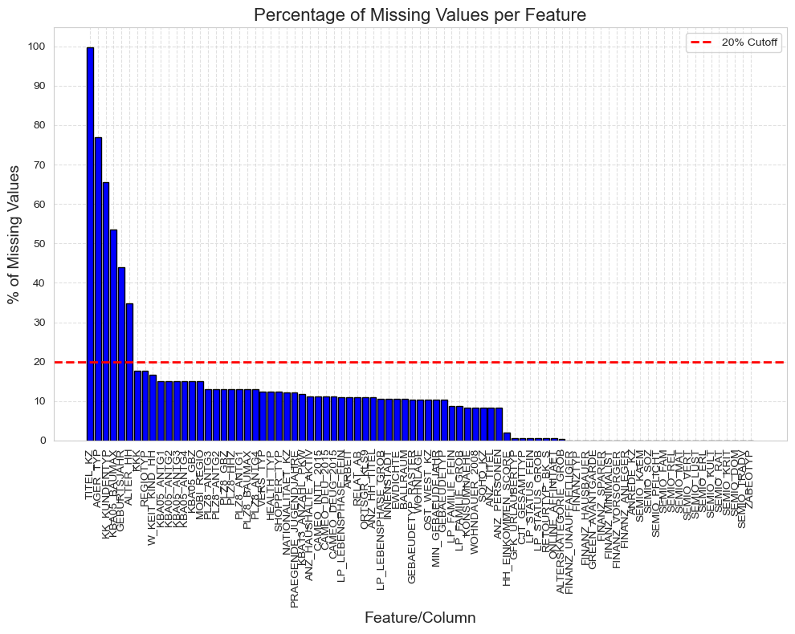

```python
# Plot Percentages
plt.figure(figsize=(10,8))

plt.bar(s_missing_per_feature_pct.index, s_missing_per_feature_pct.values, color="b", edgecolor='black')

plt.title('Percentage of Missing Values per Feature', fontsize=16)
plt.xlabel('Feature/Column', fontsize=14)
plt.ylabel('% of Missing Values', fontsize=14)

plt.xticks(rotation=90, ha="center", fontsize=10)
plt.yticks(np.arange(0, 101, step=10))

# From the above
plt.axhline(y=20, color='r', linestyle='--', linewidth=2, label='20% Cutoff')
plt.legend()

plt.grid(True, linestyle='--', alpha=0.6)
plt.tight_layout()

plt.show()
```

Now we proceed to remove the outlier columns from the dataset. We will use a custom transformer, so that we can reuse it, keep track of the features that are dropped along the course of the project and so that we can also include such transformer(s) in our future cleaning pipeline:

```python
# Set threshold and get the list of features to drop
col_nan_threshold = 20
features_to_drop = list(s_missing_per_feature_pct[s_missing_per_feature_pct > col_nan_threshold].index)
print(f"High NaN % Features to drop: {features_to_drop}")
```

```
High NaN % Features to drop: ['TITEL_KZ', 'AGER_TYP', 'KK_KUNDENTYP', 'KBA05_BAUMAX', 'GEBURTSJAHR', 'ALTER_HH']
```

```python
# Define the ColumnTransformer and use 'drop'
high_na_feature_dropper = ColumnTransformer(
    transformers=[('drop_na_features', 'drop', features_to_drop)],
    remainder='passthrough',
    verbose_feature_names_out=False
).set_output(transform='pandas')

# Drop the features using the transformer
df_population = high_na_feature_dropper.fit_transform(df_population)
df_population.head()
```

|  | ALTERSKATEGORIE_GROB | ANREDE_KZ | CJT_GESAMTTYP | FINANZ_MINIMALIST | FINANZ_SPARER | FINANZ_VORSORGER | FINANZ_ANLEGER | FINANZ_UNAUFFAELLIGER | FINANZ_HAUSBAUER | FINANZTYP | GFK_URLAUBERTYP | GREEN_AVANTGARDE | HEALTH_TYP | LP_LEBENSPHASE_FEIN | LP_LEBENSPHASE_GROB | LP_FAMILIE_FEIN | LP_FAMILIE_GROB | LP_STATUS_FEIN | LP_STATUS_GROB | NATIONALITAET_KZ | PRAEGENDE_JUGENDJAHRE | RETOURTYP_BK_S | SEMIO_SOZ | SEMIO_FAM | SEMIO_REL | SEMIO_MAT | SEMIO_VERT | SEMIO_LUST | SEMIO_ERL | … |
| --- | --- | --- | --- | --- | --- | --- | --- | --- | --- | --- | --- | --- | --- | --- | --- | --- | --- | --- | --- | --- | --- | --- | --- | --- | --- | --- | --- | --- | --- | --- |
| 0 | 2.0 | 1 | 2.0 | 3 | 4 | 3 | 5 | 5 | 3 | 4 | 10.0 | 0 | NaN | 15.0 | 4.0 | 2.0 | 2.0 | 1.0 | 1.0 | NaN | NaN | 5.0 | 2 | 6 | 7 | 5 | 1 | 5 | 3 | … |
| 1 | 1.0 | 2 | 5.0 | 1 | 5 | 2 | 5 | 4 | 5 | 1 | 10.0 | 0 | 3.0 | 21.0 | 6.0 | 5.0 | 3.0 | 2.0 | 1.0 | 1.0 | 14.0 | 1.0 | 5 | 4 | 4 | 3 | 1 | 2 | 2 | … |
| 2 | 3.0 | 2 | 3.0 | 1 | 4 | 1 | 2 | 3 | 5 | 1 | 10.0 | 1 | 3.0 | 3.0 | 1.0 | 1.0 | 1.0 | 3.0 | 2.0 | 1.0 | 15.0 | 3.0 | 4 | 1 | 3 | 3 | 4 | 4 | 6 | … |
| 3 | 4.0 | 2 | 2.0 | 4 | 2 | 5 | 2 | 1 | 2 | 6 | 1.0 | 0 | 2.0 | NaN | NaN | NaN | NaN | 9.0 | 4.0 | 1.0 | 8.0 | 2.0 | 5 | 1 | 2 | 1 | 4 | 4 | 7 | … |
| 4 | 3.0 | 1 | 5.0 | 4 | 3 | 4 | 1 | 3 | 2 | 5 | 5.0 | 0 | 3.0 | 32.0 | 10.0 | 10.0 | 5.0 | 3.0 | 2.0 | 1.0 | 8.0 | 5.0 | 6 | 4 | 4 | 2 | 7 | 4 | 4 | … |

```python
# Update the dropped columns
feature_groups[TO_DROP][NA_FEATURES].update(features_to_drop)

# Update the expected number of features
expected_n_features -= len(feature_groups[TO_DROP][NA_FEATURES])

print(f"Dropped Features: {feature_groups[TO_DROP][NA_FEATURES]}")
print(f"Expected Number of Features: {expected_n_features}")
```

```
Dropped Features: {'ALTER_HH', 'KK_KUNDENTYP', 'GEBURTSJAHR', 'KBA05_BAUMAX', 'AGER_TYP', 'TITEL_KZ'}
Expected Number of Features: 79
```

#### Discussion 1.1.2: Assess Missing Data in Each Column

As can be seen above from the graph and the summary of percentage missing values, the number of missing values is not uniformly distributed across the dataset. 39/85 columns are missing 0-10% and 40/85 columns are missing 10-20% of values. This can be remedied later with imputation. I decided to use 20% missing values as a threshold based on the information gathered.

The columns dropped are:

- **'AGER_TYP'**: Best-ager typology. >70% missing data.
- **'GEBURTSJAHR'**: Year of birth. >40% missing data.
- **'TITEL_KZ'**: Academic title flag. >99% missing data.
- **'ALTER_HH'**: Birthdate of head of household. >30% missing data.
- **'KK_KUNDENTYP'**: Consumer pattern over past 12 months. >65% missing data.
- **'KBA05_BAUMAX'**: Most common building type within microcell. >50% missing data.

#### Step 1.1.3: Assess Missing Data in Each Row

Now, you'll perform a similar assessment for the rows of the dataset. How much data is missing in each row? As with the columns, you should see some groups of points that have a very different numbers of missing values. Divide the data into two subsets: one for data points that are above some threshold for missing values, and a second subset for points below that threshold.

In order to know what to do with the outlier rows, we should see if the distribution of data values on columns that are not missing data (or are missing very little data) are similar or different between the two groups. Select at least five of these columns and compare the distribution of values.

- You can use seaborn's [`countplot()`](https://seaborn.pydata.org/generated/seaborn.countplot.html) function to create a bar chart of code frequencies and matplotlib's [`subplot()`](https://matplotlib.org/api/_as_gen/matplotlib.pyplot.subplot.html) function to put bar charts for the two subplots side by side.
- To reduce repeated code, you might want to write a function that can perform this comparison, taking as one of its arguments a column to be compared.

Depending on what you observe in your comparison, this will have implications on how you approach your conclusions later in the analysis. If the distributions of non-missing features look similar between the data with many missing values and the data with few or no missing values, then we could argue that simply dropping those points from the analysis won't present a major issue. On the other hand, if the data with many missing values looks very different from the data with few or no missing values, then we should make a note on those data as special. We'll revisit these data later on. **Either way, you should continue your analysis for now using just the subset of the data with few or no missing values.**

```python
# How much data is missing in each row of the dataset?
def get_na_per_row(df):
    # How much data is missing in each row of the dataset?
    # Get the sum of NaN values per row
    na_p_row = df.isna().sum(axis=1)
    na_p_row.sort_values(ascending=False, inplace=True)
    return na_p_row

s_na_per_row = get_na_per_row(df_population)

print(s_na_per_row.describe())
s_na_per_row.head(10)
```

```
count    891221.000000
mean          5.649894
std          13.234687
min           0.000000
25%           0.000000
50%           0.000000
75%           3.000000
max          49.000000
dtype: float64
```

```
732775    49
643174    49
472919    48
345274    47
299868    47
582092    47
681255    47
818343    47
582109    47
439981    47
dtype: int64
```

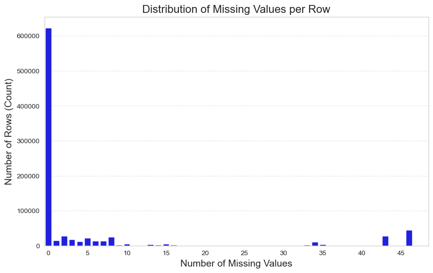

```python
# Plot the frequencies
plt.figure(figsize=(10, 6))

sns.countplot(x=s_na_per_row, color='b')

plt.title('Distribution of Missing Values per Row', fontsize=16)
plt.xlabel('Number of Missing Values', fontsize=14)
plt.ylabel('Number of Rows (Count)', fontsize=14)

plt.xticks(ticks=range(0, max(s_na_per_row) + 1, 5),
           labels=range(0, max(s_na_per_row) + 1, 5),
           rotation=0)

plt.grid(axis='y', linestyle='--', alpha=0.5)
plt.show()
```

As can be seen by the histogram, most of the rows are complete, with a small spike of rows missing. Looking at the distribution plot, we can split at around 25 missing values.

Now we can write the transformer to do this. We will use a FunctionTransformer so we can integrate it into our cleaning pipeline.

```python
# Write code to divide the data into two subsets based on the number of missing
def split_data(X, threshold, return_both=False):
        missing_per_row = X.isna().sum(axis=1)

        X_low = X[missing_per_row <= threshold]
        X_high = X[missing_per_row > threshold]

        # Return either the low missing subset or both, depending on the return_both flag.
        # We reset the index after splitting the data
        return (X_low.reset_index(drop=True), X_high.reset_index(drop=True)) if return_both else X_low.reset_index(drop=True)

splitter = FunctionTransformer(
    func=split_data,
    kw_args={'threshold':25},
    validate=False,
    feature_names_out='one-to-one'
)
```

With our FunctionTransformer created, we can proceed to split the population data into two subsets:

```python
# Now we split the dataset into two
df_pop_low_missing, df_pop_high_missing = split_data(df_population, threshold=25, return_both=True)

dropped_row_count = df_pop_high_missing.shape[0]

print(f"Total # of rows before splitting data: {df_population.shape[0]:,}")
print(f"Total # of missing values in rows: {s_na_per_row.sum().item():,}")
print(f"Number of rows dropped: {dropped_row_count:,}")
print(f"Percentage of Rows in High Missing Subset: {(df_pop_high_missing.shape[0]/df_population.shape[0]) * 100:,.2f}%")
print()
print(f"Total # of rows in Low Missing Subset: {df_pop_low_missing.shape[0]:,}")
print(f"Total # of Missing Values in Rows of Low Missing Subset: {df_pop_low_missing.isna().sum().sum():,}")
```

```
Total # of rows before splitting data: 891,221
Total # of missing values in rows: 5,035,304
Number of rows dropped: 93,260
Percentage of Rows in High Missing Subset: 10.46%

Total # of rows in Low Missing Subset: 797,961
Total # of Missing Values in Rows of Low Missing Subset: 1,011,517
```

```python
# Display info
df_pop_low_missing.info(verbose=False)
```

```
<class 'pandas.core.frame.DataFrame'>
RangeIndex: 797961 entries, 0 to 797960
Columns: 79 entries, ALTERSKATEGORIE_GROB to RELAT_AB
dtypes: float64(51), int64(24), object(4)
memory usage: 480.9+ MB
```

```python
# Explore the relevant data (low missings)
df_pop_low_missing.head()
```

|  | ALTERSKATEGORIE_GROB | ANREDE_KZ | CJT_GESAMTTYP | FINANZ_MINIMALIST | FINANZ_SPARER | FINANZ_VORSORGER | FINANZ_ANLEGER | FINANZ_UNAUFFAELLIGER | FINANZ_HAUSBAUER | FINANZTYP | GFK_URLAUBERTYP | GREEN_AVANTGARDE | HEALTH_TYP | LP_LEBENSPHASE_FEIN | LP_LEBENSPHASE_GROB | LP_FAMILIE_FEIN | LP_FAMILIE_GROB | LP_STATUS_FEIN | LP_STATUS_GROB | NATIONALITAET_KZ | PRAEGENDE_JUGENDJAHRE | RETOURTYP_BK_S | SEMIO_SOZ | SEMIO_FAM | SEMIO_REL | SEMIO_MAT | SEMIO_VERT | SEMIO_LUST | SEMIO_ERL | … |
| --- | --- | --- | --- | --- | --- | --- | --- | --- | --- | --- | --- | --- | --- | --- | --- | --- | --- | --- | --- | --- | --- | --- | --- | --- | --- | --- | --- | --- | --- | --- |
| 0 | 1.0 | 2 | 5.0 | 1 | 5 | 2 | 5 | 4 | 5 | 1 | 10.0 | 0 | 3.0 | 21.0 | 6.0 | 5.0 | 3.0 | 2.0 | 1.0 | 1.0 | 14.0 | 1.0 | 5 | 4 | 4 | 3 | 1 | 2 | 2 | … |
| 1 | 3.0 | 2 | 3.0 | 1 | 4 | 1 | 2 | 3 | 5 | 1 | 10.0 | 1 | 3.0 | 3.0 | 1.0 | 1.0 | 1.0 | 3.0 | 2.0 | 1.0 | 15.0 | 3.0 | 4 | 1 | 3 | 3 | 4 | 4 | 6 | … |
| 2 | 4.0 | 2 | 2.0 | 4 | 2 | 5 | 2 | 1 | 2 | 6 | 1.0 | 0 | 2.0 | NaN | NaN | NaN | NaN | 9.0 | 4.0 | 1.0 | 8.0 | 2.0 | 5 | 1 | 2 | 1 | 4 | 4 | 7 | … |
| 3 | 3.0 | 1 | 5.0 | 4 | 3 | 4 | 1 | 3 | 2 | 5 | 5.0 | 0 | 3.0 | 32.0 | 10.0 | 10.0 | 5.0 | 3.0 | 2.0 | 1.0 | 8.0 | 5.0 | 6 | 4 | 4 | 2 | 7 | 4 | 4 | … |
| 4 | 1.0 | 2 | 2.0 | 3 | 1 | 5 | 2 | 2 | 5 | 2 | 1.0 | 0 | 3.0 | 8.0 | 2.0 | 1.0 | 1.0 | 4.0 | 2.0 | 1.0 | 3.0 | 3.0 | 2 | 4 | 7 | 4 | 2 | 2 | 2 | … |

We have therefore decreased the number of rows from 891,221 to 797,961 (~10% decrease) and the total number of missing values from 5,035,304 to 1,011,517 (~80% decrease).

#### Comparing Distribution of Values Between Accepted and Rejected Subsets

```python
# Let's recall the missing_per_feature_pct data frame
s_missing_per_feature_pct.head()
```

```
TITEL_KZ        99.757636
AGER_TYP        76.955435
KK_KUNDENTYP    65.596749
KBA05_BAUMAX    53.468668
GEBURTSJAHR     44.020282
dtype: float64
```

```python
# Select 5 features/columns that have 0 missing values
# First we get all columns with 0 missing values
zero_missing_cols = s_missing_per_feature_pct[s_missing_per_feature_pct == 0].index.to_list()

# Then we choose 5 random ones
comparison_cols = random.choices(zero_missing_cols, k=5)
print(f"Columns/Features that will be compared: {comparison_cols}")
```

```
Columns/Features that will be compared: ['SEMIO_VERT', 'FINANZ_UNAUFFAELLIGER', 'FINANZ_VORSORGER', 'FINANZ_MINIMALIST', 'SEMIO_ERL']
```

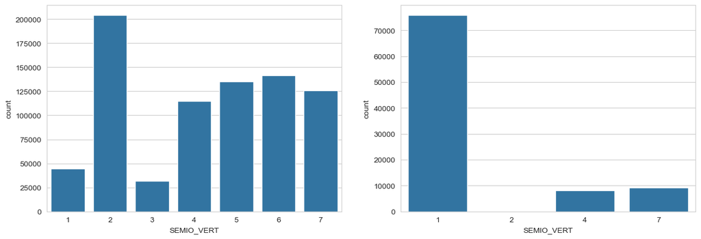

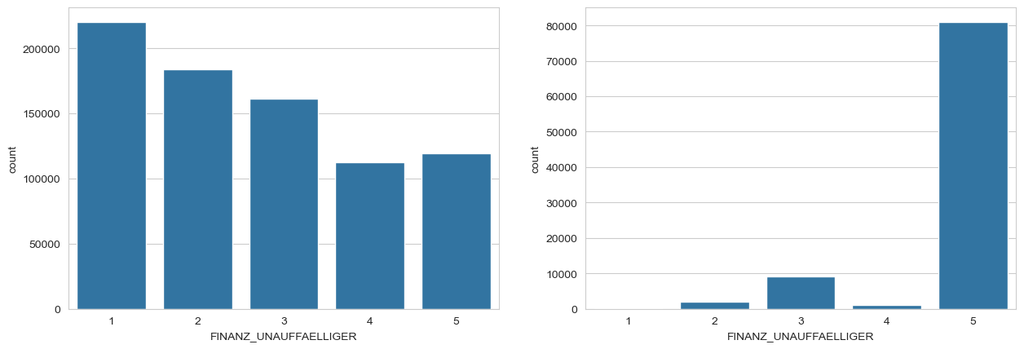

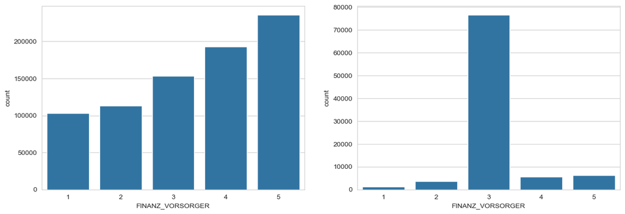

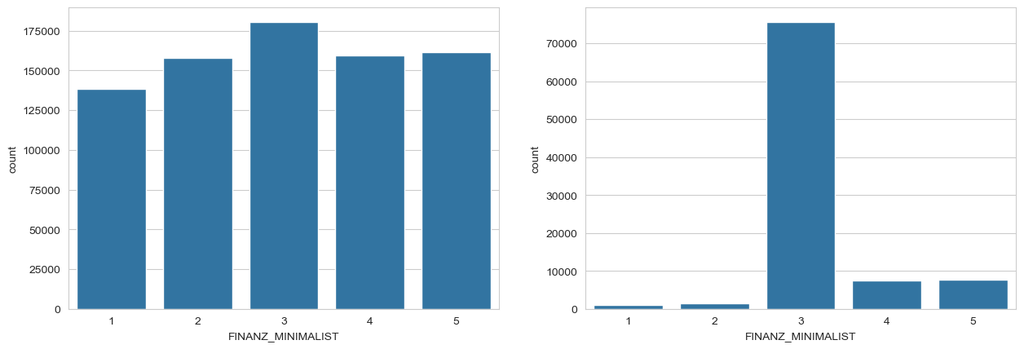

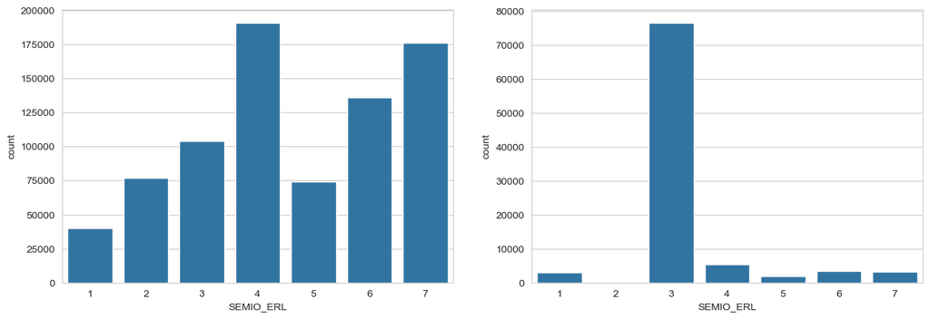

```python
# Compare the distribution of values for at least five columns where there are
# no or few missing values, between the two subsets.
def plot_subset_missing_dist(col_label):
    fig, (ax1, ax2) = plt.subplots(1, 2)
    fig.set_figwidth(15)

    sns.countplot(x=col_label, data=df_pop_low_missing, ax=ax1)
    sns.countplot(x=col_label, data=df_pop_high_missing, ax=ax2)

    plt.show()

for c in comparison_cols:
    plot_subset_missing_dist(c)
```

#### Discussion 1.1.3: Assess Missing Data in Each Row

As seen in the cells above, for na_per_row, the mean is ~5.64, so ~6 values are missing per row on average, which I would say is rather acceptable. 50% of the data has complete rows, and 75% is missing only 3 values. STD is 13.23, which is rather high. What we observe then is that there are rows that have many missing values (up to 49 max), which are simply unreliable and should be dropped (or not used, as per our subset data).

Comparison of the plots shows that the distributions between accepted and rejected are different, so we cannot simply drop those rows. However, despite the fact that we cannot drop the rows, we can notice on the rejected subset that some features have biased distributions since we can see bars on the chart that are dominated by a single value/category.

```python
# Before we move on, let's clear up memory
del df_population
del df_pop_high_missing
del s_col_missing_counts
del s_missing_per_feature
del s_missing_per_feature_pct
del s_missing_pct_bins
del s_na_per_row

gc.collect()
```

```
20872
```

### Step 1.2: Select and Re-Encode Features

Checking for missing data isn't the only way in which you can prepare a dataset for analysis. Since the unsupervised learning techniques to be used will only work on data that is encoded numerically, you need to make a few encoding changes or additional assumptions to be able to make progress. In addition, while almost all of the values in the dataset are encoded using numbers, not all of them represent numeric values. Check the third column of the feature summary (`feat_info`) for a summary of types of measurement.

- For numeric and interval data, these features can be kept without changes.
- Most of the variables in the dataset are ordinal in nature. While ordinal values may technically be non-linear in spacing, make the simplifying assumption that the ordinal variables can be treated as being interval in nature (that is, kept without any changes).
- Special handling may be necessary for the remaining two variable types: categorical, and 'mixed'.

In the first two parts of this sub-step, you will perform an investigation of the categorical and mixed-type features and make a decision on each of them, whether you will keep, drop, or re-encode each. Then, in the last part, you will create a new data frame with only the selected and engineered columns.

Data wrangling is often the trickiest part of the data analysis process, and there's a lot of it to be done here. But stick with it: once you're done with this step, you'll be ready to get to the machine learning parts of the project!

```python
# How many features are there of each data type?

# get a list of features in our pop_low_missing data
feature_list = df_pop_low_missing.columns.to_list()

# Index only those attributes that are in our pop_low_missing
feature_summary[feature_summary[FS_ATTR].isin(feature_list)][FS_TYPE].value_counts()
```

```
type
ordinal        49
categorical    18
mixed           6
numeric         6
Name: count, dtype: int64
```

#### Step 1.2.1: Re-Encode Categorical Features

For categorical data, you would ordinarily need to encode the levels as dummy variables. Depending on the number of categories, perform one of the following:

- For binary (two-level) categoricals that take numeric values, you can keep them without needing to do anything.
- There is one binary variable that takes on non-numeric values. For this one, you need to re-encode the values as numbers or create a dummy variable.
- For multi-level categoricals (three or more values), you can choose to encode the values using multiple dummy variables (e.g. via [OneHotEncoder](http://scikit-learn.org/stable/modules/generated/sklearn.preprocessing.OneHotEncoder.html)), or (to keep things straightforward) just drop them from the analysis. As always, document your choices in the Discussion section.

First, let's look at all the categorical features:

```python
# Get a list of all the categorical features
categorical_feats = list(feature_summary[
                     (feature_summary[FS_ATTR].isin(feature_list)) &
                     (feature_summary[FS_TYPE] == CATEGORICAL)][FS_ATTR])

for f in categorical_feats:
    print(f)
    pprint(feature_dictionary[f], compact=True)
    print(f"Unique Values: {df_pop_low_missing[f].nunique()} (not including NaNs)")
    print()
```

```
ANREDE_KZ
{'codes': {'-1': 'unknown (missing)',
           '0': 'unknown (cannot be determined)',
           '1': 'male',
           '2': 'female'},
 'desc': 'Gender (salutation key)'}
Unique Values: 2 (not including NaNs)

CJT_GESAMTTYP
{'codes': {'0': 'unknown',
           '1': 'Advertising- and Consumptionminimalist',
           '2': 'Advertising- and Consumptiontraditionalist',
           '3': 'advertisinginterested Store-shopper',
           '4': 'advertisinginterested Online-shopper',
           '5': 'Advertising- and Cross-Channel-Enthusiast',
           '6': 'Advertising-Enthusiast with restricted '
                'Cross-Channel-Behaviour'},
 'desc': 'Customer-Journey-Typology: preferred information and buying channels'}
Unique Values: 6 (not including NaNs)

FINANZTYP
{'codes': {'-1': 'unknown',
           '1': 'low financial interest (MINIMALIST)',
           '2': 'money-saver (SPARER)',
           '3': 'home ownership (HAUSBAUER)',
           '4': 'be prepared (VORSORGER)',
           '5': 'investor (ANLEGER)',
           '6': 'inconspicuous (UNAUFFAELLIGER)'},
 'desc': 'Most descriptive financial type for individual'}
Unique Values: 6 (not including NaNs)

GFK_URLAUBERTYP
{'codes': {'1': 'Event travelers',
           '10': 'Connoisseurs',
           '11': 'Active families',
           '12': 'Without vacation',
           '2': 'Family-oriented vacationists',
           '3': 'Winter sportspeople',
           '4': 'Culture lovers',
           '5': 'Nature fans',
```

[output cut: 174 more lines]

```
           '7C': 'Factory Worker',
           '7D': 'Rear Window',
           '7E': 'Interested Retirees',
           '8A': 'Multi-culteral',
           '8B': 'Young & Mobile',
           '8C': 'Prefab',
           '8D': 'Town Seniors',
           '9A': 'First Shared Apartment',
           '9B': 'Temporary Workers',
           '9C': 'Afternoon Talk Show',
           '9D': 'Mini-Jobber',
           '9E': 'Socking Away',
           'XX': 'unknown'},
 'desc': 'German CAMEO: Wealth / Life Stage Typology (detailed scale)'}
Unique Values: 44 (not including NaNs)
```

To make things simple, I will drop multi-level categorical that have 12+ categories, which from the output of the cell above, should filter out 2 features. We also drop redundant features or any other features I don't think would be useful.

#### Summary of Categorical Features:

```python
# Update feature groups
feature_groups[TO_DROP][CATEGORICAL].update(["LP_FAMILIE_GROB", "LP_STATUS_GROB", "GFK_URLAUBERTYP", "CAMEO_DEU_2015"])

print(f"Categorical Features we will Drop: {feature_groups[TO_DROP][CATEGORICAL]}")
```

```
Categorical Features we will Drop: {'GFK_URLAUBERTYP', 'CAMEO_DEU_2015', 'LP_FAMILIE_GROB', 'LP_STATUS_GROB'}
```

Now, rather than drop these features right away. I will actually wait to drop them until after I do the filtering of mixed-type features and one-hot encoding. That way, I can drop them all using a single ColumnTransformer.

Now that we have chosen which categorical features we do not want, we can asses the remaining categorical features:

```python
# Assess categorical variables: which are binary, which are multi-level, and
# which one needs to be re-encoded?
def get_categorical_features(df, fs, fg):
    """
    Function that sets binary, multi-level, and non-numeric categorical features
    in the feature groups dictionary
    :param df: The target DataFrame
    :param fs: The feature summary for the DataFrame
    :param fg: The feature group dictionary to update
    """

    # get a list of all features
    f_list = df.columns.to_list()

    # get a list of all categorical features
    c_features = list(fs[
                            (fs[FS_ATTR].isin(f_list)) &
                            (fs[FS_TYPE] == CATEGORICAL)
                        ][FS_ATTR])

    # iterate over each categorical
    for feat in c_features:

        # skip over the dropped categorical features
        if feat in fg[TO_DROP][CATEGORICAL]:
            # continue and do not append to any list
            continue

        # check for binary ones
        if df[feat].nunique() == 2:
            # check if numeric or not
            if df[feat].dtype == FS_OBJ:
                    fg[NOMINAL_BINARY].add(feat)
            else:
                    fg[BINARY].add(feat)
        # else, it is a multi-level categorical
        else:
            if df[feat].nunique() < 12:
                fg[MULTI_CAT].add(feat)
            else:
                fg[TO_DROP].add(feat)


get_categorical_features(df_pop_low_missing, feature_summary, feature_groups)

print(f"=========================================================")
print(f"========== ASSESSMENT OF CATEGORICAL FEATURES: ==========")
print(f"=========================================================\n")
print(f"Binary: {feature_groups[BINARY]}\n")
print(f"Multi-level: {feature_groups[MULTI_CAT]}\n")
print(f"Nominal (to re-encode): {feature_groups[NOMINAL_BINARY]}")
print(f"Multi-level Categoricals that will be dropped: {feature_groups[TO_DROP][CATEGORICAL]}")
```

```
=========================================================
========== ASSESSMENT OF CATEGORICAL FEATURES: ==========
=========================================================

Binary: {'GREEN_AVANTGARDE', 'SOHO_KZ', 'ANREDE_KZ', 'VERS_TYP'}

Multi-level: {'ZABEOTYP', 'NATIONALITAET_KZ', 'FINANZTYP', 'GEBAEUDETYP', 'LP_FAMILIE_FEIN', 'SHOPPER_TYP', 'CAMEO_DEUG_2015', 'LP_STATUS_FEIN', 'CJT_GESAMTTYP'}

Nominal (to re-encode): {'OST_WEST_KZ'}
Multi-level Categoricals that will be dropped: {'GFK_URLAUBERTYP', 'CAMEO_DEU_2015', 'LP_FAMILIE_GROB', 'LP_STATUS_GROB'}
```

As per the instructions, we will keep the binary categorical features as is, encode the multi-level categorical features and re-encode 'OST_WEST_KZ'.

#### Re-encode 'OST_WEST_KZ':

```python
# Explore 'OST_WEST_KZ':
print(df_pop_low_missing[OST_WEST].value_counts())
df_pop_low_missing[OST_WEST].head()
```

```
OST_WEST_KZ
W    629433
O    168528
Name: count, dtype: int64
```

```
0    W
1    W
2    W
3    W
4    W
Name: OST_WEST_KZ, dtype: object
```

To re-encode, we just re-encode the values as numbers. We can just re-map:

```python
# Create the ordinal encoder and ColumnTransformer to easily select the columns to encode
ost_west_map = {
    'O' : 0,
    'W' : 1
}
```

We can use a FunctionTransformer nested inside a ColumnTransformer to do this:

```python
ColumnTransformer
```

```
sklearn.compose._column_transformer.ColumnTransformer
```

```python
# We define the function to be used by the FunctionTransformer
def encode_ost_west(X, map_dict):
    '''
    Function that re-encodes OST_WEST
    :param X: DataFrame to be encoded, assuming it only contains the feature 'OST_WEST_KZ'
    :param map_dict: The dictionary to be used by the .map() function
    :return: The DataFrame with 'OST_WEST_KZ' re-encoded
    '''
    # Apply .map() to the colum and return
    return X.apply(lambda X: X.map(map_dict))

# Create the encoder using a ColumnTransformer
ost_west_encoder = ColumnTransformer(
    # Each transformer is a list of (name, transformer, columns) tuples specifying
    # the transformer objects to be applied to subsets of the data
    transformers=[
        ('re_encode_ost_west',
         FunctionTransformer(
             func=encode_ost_west, # Callable function to use for the transformation
             kw_args={"map_dict": ost_west_map}, # keyword arguments to pass to func
             validate=False # Set to false: disable input validation (Don,t convert to 2-dimensional NumPy array, as we are working with pandas DF
         ), [OST_WEST]) # The column to perform the transform on
    ],
    remainder='passthrough', # Passphrase all the other columns
    verbose_feature_names_out=False # Don't prefix feature names with the name of the transformer
)
```

```python
df_pop_low_missing = ost_west_encoder.fit_transform(df_pop_low_missing)
print(df_pop_low_missing[OST_WEST].value_counts())
df_pop_low_missing[OST_WEST].head()
```

```
OST_WEST_KZ
1    629433
0    168528
Name: count, dtype: int64
```

```
0    1
1    1
2    1
3    1
4    1
Name: OST_WEST_KZ, dtype: int64
```

As we can see, we have successfully re-encoded 'OST_WEST_KZ', and we can verify that the value counts remain the same as before.

#### Encode Multi-Level Categoricals:

To encode the remaining multi-level categoricals, we will use OneHotEncode inside a ColumnTransformer. That way we prevent making mistakes like not setting the correct feature names, or mixing up the data, as could happen if we did it all manually (this happened a lot during my testing):

```python
# Take a peek at the multi-level categoricals
df_pop_low_missing[list(feature_groups[MULTI_CAT])].head()
```

|  | ZABEOTYP | NATIONALITAET_KZ | FINANZTYP | GEBAEUDETYP | LP_FAMILIE_FEIN | SHOPPER_TYP | CAMEO_DEUG_2015 | LP_STATUS_FEIN | CJT_GESAMTTYP |
| --- | --- | --- | --- | --- | --- | --- | --- | --- | --- |
| 0 | 5 | 1.0 | 1 | 8.0 | 5.0 | 3.0 | 8 | 2.0 | 5.0 |
| 1 | 5 | 1.0 | 1 | 1.0 | 1.0 | 2.0 | 4 | 3.0 | 3.0 |
| 2 | 3 | 1.0 | 6 | 1.0 | NaN | 1.0 | 2 | 9.0 | 2.0 |
| 3 | 4 | 1.0 | 5 | 1.0 | 10.0 | 2.0 | 6 | 3.0 | 5.0 |
| 4 | 4 | 1.0 | 2 | 1.0 | 1.0 | 0.0 | 8 | 4.0 | 2.0 |

```python
# Create a dataframe of the multi-level categoricals, with columns for the number of
# unique values they have and if they have a NaN value

# First, create the dataframe for 'has_nan' column
df_multi_has_na = pd.DataFrame({
    'has_nan': df_pop_low_missing[list(feature_groups[MULTI_CAT])].isna().any()
})

# Second, create a dataframe of the unique values, rename the single column to 'n_unique'
df_multi_nunique = df_pop_low_missing[list(feature_groups[MULTI_CAT])].nunique().rename('n_unique')

# Concatenate both to create a single dataframe
df_multi_info = pd.concat([df_multi_nunique, df_multi_has_na], axis=1)
df_multi_info
```

|  | n_unique | has_nan |
| --- | --- | --- |
| ZABEOTYP | 6 | False |
| NATIONALITAET_KZ | 3 | True |
| FINANZTYP | 6 | False |
| GEBAEUDETYP | 7 | False |
| LP_FAMILIE_FEIN | 11 | True |
| SHOPPER_TYP | 4 | True |
| CAMEO_DEUG_2015 | 9 | True |
| LP_STATUS_FEIN | 10 | True |
| CJT_GESAMTTYP | 6 | True |

As per the dataframe shown above, we can see how many unique values each feature has, as well as if they have any NaN values. This is information is important for two reasons:

1. We can estimate how many dummy columns will be created by One-Hot Encoding
2. One-Hot encoding will create a dummy column for nan values, we want to avoid this. We will have to impute before we One-Hot Encode.

```python
# Free memory
del df_multi_has_na, df_multi_nunique, df_multi_info
gc.collect()
```

```
6573
```

**IMPORTANT**: As per my mentor's recommendations:

1. I will be imputing using 'most_frequent', **before** One-Hot Encoding — while sklearn's OHE can handle NaNs (creating a `_nan` column), this treats "missing" as its own category. Imputing first assigns rows to the most likely real category, avoiding unnecessary extra columns.
2. I will be using drop='first' with my OHE to avoid **multicollinearity** — if a feature has 3 categories, we only need 2 dummy columns since the third is implied when the other two are 0

- **CJT_GESAMTTYP**: We should get 5 new columns
- **FINANZTYP**: We should get 5 new columns
- **LP_FAMILIE_FEIN**: We should get 10 new columns
- **LP_STATUS_FEIN**: We should get 9 new columns
- **SHOPPER_TYP**: We should get 3 new columns
- **ZABEOTYP**: We should get 5 new columns
- **GEBAEUDETYP**: We should get 6 new columns
- **CAMEO_DEUG_2015**: We should get 8 new columns
- **NATIONALITAET_KZ**: We should get 2 new columns

In total, this adds up to 53 new columns

To One-Hot Encode the categorical features, we can use a Pipeline that first imputes and then uses a nested ColumnTransformer to apply the One-Hot encoding to the relevant columns/features:

```python
# Create the One-hot encoder
one_hot_encoder = OneHotEncoder(sparse_output=False, drop='first')

# Create the pipeline
categorical_transformer = Pipeline(steps=[
    # Impute step
    ('imputer', SimpleImputer(strategy='most_frequent')),
    # One-hot encoding step
    ('onehot',
         ColumnTransformer(
            transformers=[('onehot', one_hot_encoder, list(feature_groups[MULTI_CAT]))],
            remainder='passthrough', # Passthrough all the other columns
            verbose_feature_names_out=False # Do not prefix the transformer name
        )
     ),
]).set_output(transform="pandas") # ensure the pipeline returns a pandas DataFrame
```

```python
# Check everything is OK before
df_pop_low_missing.head()
```

|  | OST_WEST_KZ | ALTERSKATEGORIE_GROB | ANREDE_KZ | CJT_GESAMTTYP | FINANZ_MINIMALIST | FINANZ_SPARER | FINANZ_VORSORGER | FINANZ_ANLEGER | FINANZ_UNAUFFAELLIGER | FINANZ_HAUSBAUER | FINANZTYP | GFK_URLAUBERTYP | GREEN_AVANTGARDE | HEALTH_TYP | LP_LEBENSPHASE_FEIN | LP_LEBENSPHASE_GROB | LP_FAMILIE_FEIN | LP_FAMILIE_GROB | LP_STATUS_FEIN | LP_STATUS_GROB | NATIONALITAET_KZ | PRAEGENDE_JUGENDJAHRE | RETOURTYP_BK_S | SEMIO_SOZ | SEMIO_FAM | SEMIO_REL | SEMIO_MAT | SEMIO_VERT | SEMIO_LUST | … |
| --- | --- | --- | --- | --- | --- | --- | --- | --- | --- | --- | --- | --- | --- | --- | --- | --- | --- | --- | --- | --- | --- | --- | --- | --- | --- | --- | --- | --- | --- | --- |
| 0 | 1 | 1.0 | 2 | 5.0 | 1 | 5 | 2 | 5 | 4 | 5 | 1 | 10.0 | 0 | 3.0 | 21.0 | 6.0 | 5.0 | 3.0 | 2.0 | 1.0 | 1.0 | 14.0 | 1.0 | 5 | 4 | 4 | 3 | 1 | 2 | … |
| 1 | 1 | 3.0 | 2 | 3.0 | 1 | 4 | 1 | 2 | 3 | 5 | 1 | 10.0 | 1 | 3.0 | 3.0 | 1.0 | 1.0 | 1.0 | 3.0 | 2.0 | 1.0 | 15.0 | 3.0 | 4 | 1 | 3 | 3 | 4 | 4 | … |
| 2 | 1 | 4.0 | 2 | 2.0 | 4 | 2 | 5 | 2 | 1 | 2 | 6 | 1.0 | 0 | 2.0 | NaN | NaN | NaN | NaN | 9.0 | 4.0 | 1.0 | 8.0 | 2.0 | 5 | 1 | 2 | 1 | 4 | 4 | … |
| 3 | 1 | 3.0 | 1 | 5.0 | 4 | 3 | 4 | 1 | 3 | 2 | 5 | 5.0 | 0 | 3.0 | 32.0 | 10.0 | 10.0 | 5.0 | 3.0 | 2.0 | 1.0 | 8.0 | 5.0 | 6 | 4 | 4 | 2 | 7 | 4 | … |
| 4 | 1 | 1.0 | 2 | 2.0 | 3 | 1 | 5 | 2 | 2 | 5 | 2 | 1.0 | 0 | 3.0 | 8.0 | 2.0 | 1.0 | 1.0 | 4.0 | 2.0 | 1.0 | 3.0 | 3.0 | 2 | 4 | 7 | 4 | 2 | 2 | … |

```python
# Impute and Encode:
df_pop_low_encoded  = categorical_transformer.fit_transform(df_pop_low_missing)
```

Now that we have encoded the categorical features, let's get the names of the dummy features:

```python
# Get the encoded features
# Get the encoder feature names out
encoded_features = categorical_transformer.named_steps['onehot'].named_transformers_['onehot'].get_feature_names_out()
print(f"Number of OHE encoded features (out): {len(encoded_features)}")
print(f"OHE encoded features (out): {encoded_features}")
```

```
Number of OHE encoded features (out): 53
OHE encoded features (out): ['ZABEOTYP_2' 'ZABEOTYP_3' 'ZABEOTYP_4' 'ZABEOTYP_5' 'ZABEOTYP_6'
 'NATIONALITAET_KZ_2.0' 'NATIONALITAET_KZ_3.0' 'FINANZTYP_2' 'FINANZTYP_3'
 'FINANZTYP_4' 'FINANZTYP_5' 'FINANZTYP_6' 'GEBAEUDETYP_2.0'
 'GEBAEUDETYP_3.0' 'GEBAEUDETYP_4.0' 'GEBAEUDETYP_5.0' 'GEBAEUDETYP_6.0'
 'GEBAEUDETYP_8.0' 'LP_FAMILIE_FEIN_2.0' 'LP_FAMILIE_FEIN_3.0'
 'LP_FAMILIE_FEIN_4.0' 'LP_FAMILIE_FEIN_5.0' 'LP_FAMILIE_FEIN_6.0'
 'LP_FAMILIE_FEIN_7.0' 'LP_FAMILIE_FEIN_8.0' 'LP_FAMILIE_FEIN_9.0'
 'LP_FAMILIE_FEIN_10.0' 'LP_FAMILIE_FEIN_11.0' 'SHOPPER_TYP_1.0'
 'SHOPPER_TYP_2.0' 'SHOPPER_TYP_3.0' 'CAMEO_DEUG_2015_2'
 'CAMEO_DEUG_2015_3' 'CAMEO_DEUG_2015_4' 'CAMEO_DEUG_2015_5'
 'CAMEO_DEUG_2015_6' 'CAMEO_DEUG_2015_7' 'CAMEO_DEUG_2015_8'
 'CAMEO_DEUG_2015_9' 'LP_STATUS_FEIN_2.0' 'LP_STATUS_FEIN_3.0'
 'LP_STATUS_FEIN_4.0' 'LP_STATUS_FEIN_5.0' 'LP_STATUS_FEIN_6.0'
 'LP_STATUS_FEIN_7.0' 'LP_STATUS_FEIN_8.0' 'LP_STATUS_FEIN_9.0'
 'LP_STATUS_FEIN_10.0' 'CJT_GESAMTTYP_2.0' 'CJT_GESAMTTYP_3.0'
 'CJT_GESAMTTYP_4.0' 'CJT_GESAMTTYP_5.0' 'CJT_GESAMTTYP_6.0']
```

```python
# Check the encoded features
df_pop_low_encoded[encoded_features].head()
```

|  | ZABEOTYP_2 | ZABEOTYP_3 | ZABEOTYP_4 | ZABEOTYP_5 | ZABEOTYP_6 | NATIONALITAET_KZ_2.0 | NATIONALITAET_KZ_3.0 | FINANZTYP_2 | FINANZTYP_3 | FINANZTYP_4 | FINANZTYP_5 | FINANZTYP_6 | GEBAEUDETYP_2.0 | GEBAEUDETYP_3.0 | GEBAEUDETYP_4.0 | GEBAEUDETYP_5.0 | GEBAEUDETYP_6.0 | GEBAEUDETYP_8.0 | LP_FAMILIE_FEIN_2.0 | LP_FAMILIE_FEIN_3.0 | LP_FAMILIE_FEIN_4.0 | LP_FAMILIE_FEIN_5.0 | LP_FAMILIE_FEIN_6.0 | LP_FAMILIE_FEIN_7.0 | LP_FAMILIE_FEIN_8.0 | LP_FAMILIE_FEIN_9.0 | LP_FAMILIE_FEIN_10.0 | LP_FAMILIE_FEIN_11.0 | SHOPPER_TYP_1.0 | … |
| --- | --- | --- | --- | --- | --- | --- | --- | --- | --- | --- | --- | --- | --- | --- | --- | --- | --- | --- | --- | --- | --- | --- | --- | --- | --- | --- | --- | --- | --- | --- |
| 0 | 0.0 | 0.0 | 0.0 | 1.0 | 0.0 | 0.0 | 0.0 | 0.0 | 0.0 | 0.0 | 0.0 | 0.0 | 0.0 | 0.0 | 0.0 | 0.0 | 0.0 | 1.0 | 0.0 | 0.0 | 0.0 | 1.0 | 0.0 | 0.0 | 0.0 | 0.0 | 0.0 | 0.0 | 0.0 | … |
| 1 | 0.0 | 0.0 | 0.0 | 1.0 | 0.0 | 0.0 | 0.0 | 0.0 | 0.0 | 0.0 | 0.0 | 0.0 | 0.0 | 0.0 | 0.0 | 0.0 | 0.0 | 0.0 | 0.0 | 0.0 | 0.0 | 0.0 | 0.0 | 0.0 | 0.0 | 0.0 | 0.0 | 0.0 | 0.0 | … |
| 2 | 0.0 | 1.0 | 0.0 | 0.0 | 0.0 | 0.0 | 0.0 | 0.0 | 0.0 | 0.0 | 0.0 | 1.0 | 0.0 | 0.0 | 0.0 | 0.0 | 0.0 | 0.0 | 0.0 | 0.0 | 0.0 | 0.0 | 0.0 | 0.0 | 0.0 | 0.0 | 0.0 | 0.0 | 1.0 | … |
| 3 | 0.0 | 0.0 | 1.0 | 0.0 | 0.0 | 0.0 | 0.0 | 0.0 | 0.0 | 0.0 | 1.0 | 0.0 | 0.0 | 0.0 | 0.0 | 0.0 | 0.0 | 0.0 | 0.0 | 0.0 | 0.0 | 0.0 | 0.0 | 0.0 | 0.0 | 0.0 | 1.0 | 0.0 | 0.0 | … |
| 4 | 0.0 | 0.0 | 1.0 | 0.0 | 0.0 | 0.0 | 0.0 | 1.0 | 0.0 | 0.0 | 0.0 | 0.0 | 0.0 | 0.0 | 0.0 | 0.0 | 0.0 | 0.0 | 0.0 | 0.0 | 0.0 | 0.0 | 0.0 | 0.0 | 0.0 | 0.0 | 0.0 | 0.0 | 0.0 | … |

As we can see, we have successfully One-Hot encoded the categorical features, and we do indeed get 53 columns, just as expected!

```python
# Update feature groups with the list of the encoded feature names
feature_groups[ENCODED_FEATURES].update(sorted(encoded_features))
```

```python
# Check everything is OK:
df_pop_low_encoded.head()
```

|  | ZABEOTYP_2 | ZABEOTYP_3 | ZABEOTYP_4 | ZABEOTYP_5 | ZABEOTYP_6 | NATIONALITAET_KZ_2.0 | NATIONALITAET_KZ_3.0 | FINANZTYP_2 | FINANZTYP_3 | FINANZTYP_4 | FINANZTYP_5 | FINANZTYP_6 | GEBAEUDETYP_2.0 | GEBAEUDETYP_3.0 | GEBAEUDETYP_4.0 | GEBAEUDETYP_5.0 | GEBAEUDETYP_6.0 | GEBAEUDETYP_8.0 | LP_FAMILIE_FEIN_2.0 | LP_FAMILIE_FEIN_3.0 | LP_FAMILIE_FEIN_4.0 | LP_FAMILIE_FEIN_5.0 | LP_FAMILIE_FEIN_6.0 | LP_FAMILIE_FEIN_7.0 | LP_FAMILIE_FEIN_8.0 | LP_FAMILIE_FEIN_9.0 | LP_FAMILIE_FEIN_10.0 | LP_FAMILIE_FEIN_11.0 | SHOPPER_TYP_1.0 | … |
| --- | --- | --- | --- | --- | --- | --- | --- | --- | --- | --- | --- | --- | --- | --- | --- | --- | --- | --- | --- | --- | --- | --- | --- | --- | --- | --- | --- | --- | --- | --- |
| 0 | 0.0 | 0.0 | 0.0 | 1.0 | 0.0 | 0.0 | 0.0 | 0.0 | 0.0 | 0.0 | 0.0 | 0.0 | 0.0 | 0.0 | 0.0 | 0.0 | 0.0 | 1.0 | 0.0 | 0.0 | 0.0 | 1.0 | 0.0 | 0.0 | 0.0 | 0.0 | 0.0 | 0.0 | 0.0 | … |
| 1 | 0.0 | 0.0 | 0.0 | 1.0 | 0.0 | 0.0 | 0.0 | 0.0 | 0.0 | 0.0 | 0.0 | 0.0 | 0.0 | 0.0 | 0.0 | 0.0 | 0.0 | 0.0 | 0.0 | 0.0 | 0.0 | 0.0 | 0.0 | 0.0 | 0.0 | 0.0 | 0.0 | 0.0 | 0.0 | … |
| 2 | 0.0 | 1.0 | 0.0 | 0.0 | 0.0 | 0.0 | 0.0 | 0.0 | 0.0 | 0.0 | 0.0 | 1.0 | 0.0 | 0.0 | 0.0 | 0.0 | 0.0 | 0.0 | 0.0 | 0.0 | 0.0 | 0.0 | 0.0 | 0.0 | 0.0 | 0.0 | 0.0 | 0.0 | 1.0 | … |
| 3 | 0.0 | 0.0 | 1.0 | 0.0 | 0.0 | 0.0 | 0.0 | 0.0 | 0.0 | 0.0 | 1.0 | 0.0 | 0.0 | 0.0 | 0.0 | 0.0 | 0.0 | 0.0 | 0.0 | 0.0 | 0.0 | 0.0 | 0.0 | 0.0 | 0.0 | 0.0 | 1.0 | 0.0 | 0.0 | … |
| 4 | 0.0 | 0.0 | 1.0 | 0.0 | 0.0 | 0.0 | 0.0 | 1.0 | 0.0 | 0.0 | 0.0 | 0.0 | 0.0 | 0.0 | 0.0 | 0.0 | 0.0 | 0.0 | 0.0 | 0.0 | 0.0 | 0.0 | 0.0 | 0.0 | 0.0 | 0.0 | 0.0 | 0.0 | 0.0 | … |

We can now update our expected number of features, **NOTING One-Hot encoding dropped the original features**. We should therefore expect to go from 79 features to 123 (+53 one-hot encoded dummies -9 original ones).

```python
# Remind me how many features we expected before encoding categoricals:
print(f"Expected number features before encoding: {expected_n_features}")

# After encoding, we should have 53 more features, minus the 9 original ones
expected_n_features += len(feature_groups[ENCODED_FEATURES]) - len(feature_groups[MULTI_CAT])
print(f"After encoding we should have: {expected_n_features}")
```

```
Expected number features before encoding: 79
After encoding we should have: 123
```

Indeed, it seems the OneHotEncoding works, and we should eventually get the 123 features.

```python
del df_pop_low_missing
gc.collect()
```

```
12
```

#### Discussion 1.2.1: Re-Encode Categorical Features

In summary:

1. **Binary Categoricals**: 'SOHO_KZ', 'VERS_TYP', 'GREEN_AVANTGARDE', 'ANREDE_KZ', Kept as is.
2. **Multi-Level Categoricals**: Kept all except the ones dropped (listed below). Encoded using One-Hot-Encode.
3. **Non-numerical Categoricals**: Only one, 'OST_WEST_KZ', we re-encoded -> ('O', 'W') to (0, 1)

We will drop at a later step: 'LP_STATUS_GROB', 'LP_FAMILIE_GROB', 'CAMEO_DEU_2015', 'GFK_URLAUBERTYP'

#### Step 1.2.2: Engineer Mixed-Type Features

There are a handful of features that are marked as "mixed" in the feature summary that require special treatment in order to be included in the analysis. There are two in particular that deserve attention; the handling of the rest are up to your own choices:

- "PRAEGENDE_JUGENDJAHRE" combines information on three dimensions: generation by decade, movement (mainstream vs. avantgarde), and nation (east vs. west). While there aren't enough levels to disentangle east from west, you should create two new variables to capture the other two dimensions: an interval-type variable for decade, and a binary variable for movement.
- "CAMEO_INTL_2015" combines information on two axes: wealth and life stage. Break up the two-digit codes by their 'tens'-place and 'ones'-place digits into two new ordinal variables (which, for the purposes of this project, is equivalent to just treating them as their raw numeric values).
- If you decide to keep or engineer new features around the other mixed-type features, make sure you note your steps in the Discussion section.

Be sure to check `Data_Dictionary.md` for the details needed to finish these tasks.

```python
# Get all the mixed type features in the dataframe
def get_mixed_features(df, fs):
    # Get all features in the dataframe, not explicitly dropped
    feats = [f for f in df.columns.to_list() if f not in feature_groups[TO_DROP][NA_FEATURES]]
    return list(fs[
                    (fs[FS_ATTR].isin(feats)) &
                    (fs[FS_TYPE] == MIXED)][FS_ATTR])

mixed_features = get_mixed_features(df_pop_low_encoded, feature_summary)
print(f"Mixed Type Features: {mixed_features}")
```

```
Mixed Type Features: ['LP_LEBENSPHASE_FEIN', 'LP_LEBENSPHASE_GROB', 'PRAEGENDE_JUGENDJAHRE', 'WOHNLAGE', 'CAMEO_INTL_2015', 'PLZ8_BAUMAX']
```

```python
# Perform same analysis as we did with multi-categoricals

# Create a dataframe showing if a feature has NaN values
df_mixed_has_na = pd.DataFrame({
    'has_nan': df_pop_low_encoded[mixed_features].isna().any()
})

# Create a dataframe showing the number of unique values per feature
df_mixed_nunique = pd.DataFrame({
    'n_unique': df_pop_low_encoded[mixed_features].nunique()
})

# Join both
df_multi_info = pd.concat([df_mixed_nunique, df_mixed_has_na], axis=1)
df_multi_info
```

|  | n_unique | has_nan |
| --- | --- | --- |
| LP_LEBENSPHASE_FEIN | 40 | False |
| LP_LEBENSPHASE_GROB | 12 | False |
| PRAEGENDE_JUGENDJAHRE | 15 | False |
| WOHNLAGE | 8 | False |
| CAMEO_INTL_2015 | 21 | False |
| PLZ8_BAUMAX | 5 | False |

#### Summary of Mixed Features:

- **LP_LEBENSPHASE_FEIN** and **LP_LEBENSPHASE_GROB**: Life stage (fine and rough). Complicated and FEIN has many codes. Will drop both.
- **PRAEGENDE_JUGENDJAHRE**: We deal with this one further below.
- **WOHNLAGE**: Will drop.
- **CAMEO_INTL_2015**: We deal with this one further below.
- **PLZ8_BAUMAX**: Building Type. Redundat with other features. Drop.

```python
# Update the feature groups to include the mixed-types we don't want
feature_groups[TO_DROP][MIXED].update(['LP_LEBENSPHASE_FEIN', 'LP_LEBENSPHASE_GROB', 'WOHNLAGE', 'PLZ8_BAUMAX'])
```

**IMPORTANT NOTE**: We will **NOT** yet drop these features, as we can do this in the end, dropping them along with the categoricals we also decided to drop. We update expected number of features for our reference.

```python
# Update expected feature count
expected_n_features -= len(feature_groups[TO_DROP][MIXED])
expected_n_features
```

```
119
```

```python
# Update feature_groups with those features that we will engineer
feature_groups[TO_ENGINEER].update([PRA_JUG, CAM_INT])
feature_groups[TO_ENGINEER]
```

```
{'CAMEO_INTL_2015', 'PRAEGENDE_JUGENDJAHRE'}
```

Now that we have decided which mixed type features we will engineer, we proceed:

#### Explore PRAEGENDE_JUGENDJAHRE:

```python
# Investigate "PRAEGENDE_JUGENDJAHRE" and engineer two new variables.
# View unique values
df_pop_low_encoded[PRA_JUG].unique()
```

```
array([14.0, 15.0, 8.0, 3.0, 10.0, 11.0, 5.0, 9.0, 6.0, 4.0, 2.0, 1.0,
       12.0, 13.0, 7.0], dtype=object)
```

```python
# Explore this feature:
feature_dictionary[PRA_JUG]
```

```
{'desc': "Dominating movement of person's youth (avantgarde vs. mainstream; east vs. west)",
 'codes': {'-1': 'unknown',
  '0': 'unknown',
  '1': '40s - war years (Mainstream, E+W)',
  '2': '40s - reconstruction years (Avantgarde, E+W)',
  '3': '50s - economic miracle (Mainstream, E+W)',
  '4': '50s - milk bar / Individualisation (Avantgarde, E+W)',
  '5': '60s - economic miracle (Mainstream, E+W)',
  '6': '60s - generation 68 / student protestors (Avantgarde, W)',
  '7': '60s - opponents to the building of the Wall (Avantgarde, E)',
  '8': '70s - family orientation (Mainstream, E+W)',
  '9': '70s - peace movement (Avantgarde, E+W)',
  '10': '80s - Generation Golf (Mainstream, W)',
  '11': '80s - ecological awareness (Avantgarde, W)',
  '12': '80s - FDJ / communist party youth organisation (Mainstream, E)',
  '13': '80s - Swords into ploughshares (Avantgarde, E)',
  '14': '90s - digital media kids (Mainstream, E+W)',
  '15': '90s - ecological awareness (Avantgarde, E+W)'}}
```

#### Explore CAMEO_INTL_2015:

```python
# Investigate "CAMEO_INTL_2015" and engineer two new variables.
# View unique values
df_pop_low_encoded[CAM_INT].unique()
```

```
array(['51', '24', '12', '43', '54', '22', '14', '13', '15', '33', '41',
       '34', '55', '25', '23', '31', '52', '35', '45', '44', '32'],
      dtype=object)
```

```python
# Explore this feature
feature_dictionary[CAM_INT]
```

```
{'desc': 'German CAMEO: Wealth / Life Stage Typology mapped to international code',
 'codes': {'-1': 'unknown',
  '11': 'Wealthy Households - Pre-Family Couples & Singles',
  '12': 'Wealthy Households - Young Couples With Children',
  '13': 'Wealthy Households - Families With School Age Children',
  '14': 'Wealthy Households - Older Families & Mature Couples',
  '15': 'Wealthy Households - Elders In Retirement',
  '21': 'Prosperous Households - Pre-Family Couples & Singles',
  '22': 'Prosperous Households - Young Couples With Children',
  '23': 'Prosperous Households - Families With School Age Children',
  '24': 'Prosperous Households - Older Families & Mature Couples',
  '25': 'Prosperous Households - Elders In Retirement',
  '31': 'Comfortable Households - Pre-Family Couples & Singles',
  '32': 'Comfortable Households - Young Couples With Children',
  '33': 'Comfortable Households - Families With School Age Children',
  '34': 'Comfortable Households - Older Families & Mature Couples',
  '35': 'Comfortable Households - Elders In Retirement',
  '41': 'Less Affluent Households - Pre-Family Couples & Singles',
  '42': 'Less Affluent Households - Young Couples With Children',
  '43': 'Less Affluent Households - Families With School Age Children',
  '44': 'Less Affluent Households - Older Families & Mature Couples',
  '45': 'Less Affluent Households - Elders In Retirement',
  '51': 'Poorer Households - Pre-Family Couples & Singles',
  '52': 'Poorer Households - Young Couples With Children',
  '53': 'Poorer Households - Families With School Age Children',
  '54': 'Poorer Households - Older Families & Mature Couples',
  '55': 'Poorer Households - Elders In Retirement',
  'XX': 'unknown'}}
```

We are reengineering columns: ['PRAEGENDE_JUGENDJAHRE', 'CAMEO_INTL_2015']

After encoding, we should obtain the columns:

**For 'PRAEGENDE_JUGENDJAHRE'**:

- **PRAEGENDE_DECADE**: Interval
- **PRAEGENDE_MOVEMENT**: Binary

**For 'CAMEO_INTL_2015'**:

- **CAMEO_WEALTH**: Ordinal
- **CAMEO_LIFESTAGE**: Ordinal

We should therefore go from 119 features in our data, up to 123 (we add 4 new ones - the original ones will be dropped during engineering)

To take advantage of the tools sklearn has available for us, I will be using:

- A custom encoder: implementing a custom engineer so that we can add it to a pipeline. I could have used a FunctionTransformer, but a custom transformer allows us to implement get_features_names_out(). This is very important because we are **manually** creating 4 columns. With this method, we can include our custom engineer in a pipeline and propagate the correct columns down the pipeline.

#### PRAEGENDE_JUGENDJAHRE Mapping:

```python
# Create mapping dictionaries, using the Data_Dictionary.md as reference

# FOR PRAEGENDE_JUGENDJAHRE:
# Map to decades 40s to 90s (ordinal)
mappings[PRA_JUG][P_DECADE] = {
    1: 1940, 2: 1940, 3: 1950, 4: 1950, 5: 1960, 6: 1960, 7: 1960, 8: 1970, 9: 1970, 10: 1980, 11: 1980, 12: 1980, 13: 1980, 14: 1990, 15: 1990}

# Map to movement (binary)
# 1 = Mainstream, 0 = Avantgrade
mappings[PRA_JUG][P_MOVEMENT] = { 1: 1, 2: 0, 3: 1, 4: 0, 5: 1, 6: 0, 7: 0, 8: 1, 9: 0, 10: 1, 11: 0, 12: 1, 13: 0, 14: 1, 15: 0}
```

#### CAMEO_INTL_2015 Mapping:

```python
# CAMEO_INTL_2015
# Encode WEALTH AND LIFE_STAGE features by splitting the digits
mappings[CAM_INT][C_WEALTH] = lambda x: int(x) // 10 if not pd.isna(x) else np.nan

mappings[CAM_INT][C_LIFE] = lambda x: int(x) % 10 if not pd.isna(x) else np.nan
```

And now, we create our own Custom Encoder:

```python
class MixedFeatureEncodingEngineer(BaseEstimator, TransformerMixin):
    """
    Class that engineers mixed features
    """

    def __init__(self, mappings):
        self.mappings = mappings

    def fit(self, X, y=None):
        # Get the input features
        self.feature_names_in_ = X.columns.tolist()
        return self

    def transform(self, X):
        # Create new columns by using df.map() and the mappings defined earlier
        # Iterate over each nested dictionary
        for original_feature, new_feature_maps in self.mappings.items():
            # Iterate over each mapping dictionary for that new feature
            for new_feature, new_feature_map in new_feature_maps.items():
                # Perform the map
                X[new_feature] = X[original_feature].map(new_feature_map)

            # Drop the original feature
            try:
                X = X.drop(original_feature, axis=1)
            except KeyError:
                print(f"Could not drop: {original_feature}")

        return X.sort_index(axis=1)

    def get_feature_names_out(self, input_features=None):
        # Return output feature names by adding the new ones
        # Filter out the original features and extend the new ones
        output_features = [feature for feature in self.feature_names_in_
                          if feature not in [PRA_JUG, CAM_INT]]

        output_features.extend([P_DECADE, P_MOVEMENT, C_WEALTH, C_LIFE])

        return sorted(output_features)

mixed_feature_engineer = MixedFeatureEncodingEngineer(mappings=mappings)
```

#### Engineer Mixed Features:

With our custom engineer created, we can now engineer the new features:

```python
# Check all is well beforehand:
df_pop_low_encoded.head()
```

|  | ZABEOTYP_2 | ZABEOTYP_3 | ZABEOTYP_4 | ZABEOTYP_5 | ZABEOTYP_6 | NATIONALITAET_KZ_2.0 | NATIONALITAET_KZ_3.0 | FINANZTYP_2 | FINANZTYP_3 | FINANZTYP_4 | FINANZTYP_5 | FINANZTYP_6 | GEBAEUDETYP_2.0 | GEBAEUDETYP_3.0 | GEBAEUDETYP_4.0 | GEBAEUDETYP_5.0 | GEBAEUDETYP_6.0 | GEBAEUDETYP_8.0 | LP_FAMILIE_FEIN_2.0 | LP_FAMILIE_FEIN_3.0 | LP_FAMILIE_FEIN_4.0 | LP_FAMILIE_FEIN_5.0 | LP_FAMILIE_FEIN_6.0 | LP_FAMILIE_FEIN_7.0 | LP_FAMILIE_FEIN_8.0 | LP_FAMILIE_FEIN_9.0 | LP_FAMILIE_FEIN_10.0 | LP_FAMILIE_FEIN_11.0 | SHOPPER_TYP_1.0 | … |
| --- | --- | --- | --- | --- | --- | --- | --- | --- | --- | --- | --- | --- | --- | --- | --- | --- | --- | --- | --- | --- | --- | --- | --- | --- | --- | --- | --- | --- | --- | --- |
| 0 | 0.0 | 0.0 | 0.0 | 1.0 | 0.0 | 0.0 | 0.0 | 0.0 | 0.0 | 0.0 | 0.0 | 0.0 | 0.0 | 0.0 | 0.0 | 0.0 | 0.0 | 1.0 | 0.0 | 0.0 | 0.0 | 1.0 | 0.0 | 0.0 | 0.0 | 0.0 | 0.0 | 0.0 | 0.0 | … |
| 1 | 0.0 | 0.0 | 0.0 | 1.0 | 0.0 | 0.0 | 0.0 | 0.0 | 0.0 | 0.0 | 0.0 | 0.0 | 0.0 | 0.0 | 0.0 | 0.0 | 0.0 | 0.0 | 0.0 | 0.0 | 0.0 | 0.0 | 0.0 | 0.0 | 0.0 | 0.0 | 0.0 | 0.0 | 0.0 | … |
| 2 | 0.0 | 1.0 | 0.0 | 0.0 | 0.0 | 0.0 | 0.0 | 0.0 | 0.0 | 0.0 | 0.0 | 1.0 | 0.0 | 0.0 | 0.0 | 0.0 | 0.0 | 0.0 | 0.0 | 0.0 | 0.0 | 0.0 | 0.0 | 0.0 | 0.0 | 0.0 | 0.0 | 0.0 | 1.0 | … |
| 3 | 0.0 | 0.0 | 1.0 | 0.0 | 0.0 | 0.0 | 0.0 | 0.0 | 0.0 | 0.0 | 1.0 | 0.0 | 0.0 | 0.0 | 0.0 | 0.0 | 0.0 | 0.0 | 0.0 | 0.0 | 0.0 | 0.0 | 0.0 | 0.0 | 0.0 | 0.0 | 1.0 | 0.0 | 0.0 | … |
| 4 | 0.0 | 0.0 | 1.0 | 0.0 | 0.0 | 0.0 | 0.0 | 1.0 | 0.0 | 0.0 | 0.0 | 0.0 | 0.0 | 0.0 | 0.0 | 0.0 | 0.0 | 0.0 | 0.0 | 0.0 | 0.0 | 0.0 | 0.0 | 0.0 | 0.0 | 0.0 | 0.0 | 0.0 | 0.0 | … |

Everything is OK, we still have 123 features remaining (pending the removal of the 4 mixed features we did not keep).

```python
# Perform the engineering
df_pop_engineered = mixed_feature_engineer.fit_transform(df_pop_low_encoded)

# Create a reference list of the new engineered features
engineered_features = [P_DECADE, P_MOVEMENT, C_WEALTH, C_LIFE]

# Check the new features:
df_pop_engineered[engineered_features].head()
```

|  | PRAEGENDE_DECADE | PRAEGENDE_MOVEMENT | CAMEO_WEALTH | CAMEO_LIFESTAGE |
| --- | --- | --- | --- | --- |
| 0 | 1990 | 1 | 5 | 1 |
| 1 | 1990 | 0 | 2 | 4 |
| 2 | 1970 | 1 | 1 | 2 |
| 3 | 1970 | 1 | 4 | 3 |
| 4 | 1950 | 1 | 5 | 4 |

We check our data, to make sure everything is OK: **IMPORTANT NOTE**: We have **NOT** yet dropped the mixed features we did not want to keep. So in reality, our data should have 79 features before all the encoding and enginner, PLUS 53 features from One-Hot Encoding, MINUS 9 original features removed after One-Hot Encoding, PLUS 4 features from engineering, MINUS the 2 original mixed features we engineered. We have **NOT** yet dropped the 4 categorical and the other 4 mixed type features we decided to drop. This should result in our real data having 125 features as of right now:

```python
# And lastly, check that everything is OK
df_pop_engineered.head()
```

|  | ALTERSKATEGORIE_GROB | ANREDE_KZ | ANZ_HAUSHALTE_AKTIV | ANZ_HH_TITEL | ANZ_PERSONEN | ANZ_TITEL | ARBEIT | BALLRAUM | CAMEO_DEUG_2015_2 | CAMEO_DEUG_2015_3 | CAMEO_DEUG_2015_4 | CAMEO_DEUG_2015_5 | CAMEO_DEUG_2015_6 | CAMEO_DEUG_2015_7 | CAMEO_DEUG_2015_8 | CAMEO_DEUG_2015_9 | CAMEO_DEU_2015 | CAMEO_LIFESTAGE | CAMEO_WEALTH | CJT_GESAMTTYP_2.0 | CJT_GESAMTTYP_3.0 | CJT_GESAMTTYP_4.0 | CJT_GESAMTTYP_5.0 | CJT_GESAMTTYP_6.0 | EWDICHTE | FINANZTYP_2 | FINANZTYP_3 | FINANZTYP_4 | FINANZTYP_5 | … |
| --- | --- | --- | --- | --- | --- | --- | --- | --- | --- | --- | --- | --- | --- | --- | --- | --- | --- | --- | --- | --- | --- | --- | --- | --- | --- | --- | --- | --- | --- | --- |
| 0 | 1.0 | 2 | 11.0 | 0.0 | 2.0 | 0.0 | 3.0 | 6.0 | 0.0 | 0.0 | 0.0 | 0.0 | 0.0 | 0.0 | 1.0 | 0.0 | 8A | 1 | 5 | 0.0 | 0.0 | 0.0 | 1.0 | 0.0 | 3.0 | 0.0 | 0.0 | 0.0 | 0.0 | … |
| 1 | 3.0 | 2 | 10.0 | 0.0 | 1.0 | 0.0 | 3.0 | 2.0 | 0.0 | 0.0 | 1.0 | 0.0 | 0.0 | 0.0 | 0.0 | 0.0 | 4C | 4 | 2 | 0.0 | 1.0 | 0.0 | 0.0 | 0.0 | 4.0 | 0.0 | 0.0 | 0.0 | 0.0 | … |
| 2 | 4.0 | 2 | 1.0 | 0.0 | 0.0 | 0.0 | 2.0 | 4.0 | 1.0 | 0.0 | 0.0 | 0.0 | 0.0 | 0.0 | 0.0 | 0.0 | 2A | 2 | 1 | 1.0 | 0.0 | 0.0 | 0.0 | 0.0 | 2.0 | 0.0 | 0.0 | 0.0 | 0.0 | … |
| 3 | 3.0 | 1 | 3.0 | 0.0 | 4.0 | 0.0 | 4.0 | 2.0 | 0.0 | 0.0 | 0.0 | 0.0 | 1.0 | 0.0 | 0.0 | 0.0 | 6B | 3 | 4 | 0.0 | 0.0 | 0.0 | 1.0 | 0.0 | 5.0 | 0.0 | 0.0 | 0.0 | 1.0 | … |
| 4 | 1.0 | 2 | 5.0 | 0.0 | 1.0 | 0.0 | 2.0 | 6.0 | 0.0 | 0.0 | 0.0 | 0.0 | 0.0 | 0.0 | 1.0 | 0.0 | 8C | 4 | 5 | 1.0 | 0.0 | 0.0 | 0.0 | 0.0 | 2.0 | 1.0 | 0.0 | 0.0 | 0.0 | … |

We have now successfully engineered the mixed type features, and get 125 real columns as expected.

Since new features have been engineered, we perform necessary updates. We now finally drop the 4 categorical and 4 other mixed-type features we decided not to keep. For this, we can use another ColumnTransformer:

```python
# We can now drop all the other features, since we are not doing any more feature selection or encoding
other_features_to_drop = list(feature_groups[TO_DROP][CATEGORICAL]) + list(feature_groups[TO_DROP][MIXED])
print(f"Features that will be dropped: {other_features_to_drop}")

other_features_dropper = ColumnTransformer(
    transformers=
    [
        ('drop_features', 'drop', list(feature_groups[TO_DROP][CATEGORICAL]) + list(feature_groups[TO_DROP][MIXED]))
    ],
    remainder='passthrough',
    verbose_feature_names_out=False
)

df_pop_engineered = other_features_dropper.fit_transform(df_pop_engineered)

df_pop_engineered.head()
```

```
Features that will be dropped: ['GFK_URLAUBERTYP', 'CAMEO_DEU_2015', 'LP_FAMILIE_GROB', 'LP_STATUS_GROB', 'LP_LEBENSPHASE_FEIN', 'PLZ8_BAUMAX', 'LP_LEBENSPHASE_GROB', 'WOHNLAGE']
```

|  | ALTERSKATEGORIE_GROB | ANREDE_KZ | ANZ_HAUSHALTE_AKTIV | ANZ_HH_TITEL | ANZ_PERSONEN | ANZ_TITEL | ARBEIT | BALLRAUM | CAMEO_DEUG_2015_2 | CAMEO_DEUG_2015_3 | CAMEO_DEUG_2015_4 | CAMEO_DEUG_2015_5 | CAMEO_DEUG_2015_6 | CAMEO_DEUG_2015_7 | CAMEO_DEUG_2015_8 | CAMEO_DEUG_2015_9 | CAMEO_LIFESTAGE | CAMEO_WEALTH | CJT_GESAMTTYP_2.0 | CJT_GESAMTTYP_3.0 | CJT_GESAMTTYP_4.0 | CJT_GESAMTTYP_5.0 | CJT_GESAMTTYP_6.0 | EWDICHTE | FINANZTYP_2 | FINANZTYP_3 | FINANZTYP_4 | FINANZTYP_5 | FINANZTYP_6 | … |
| --- | --- | --- | --- | --- | --- | --- | --- | --- | --- | --- | --- | --- | --- | --- | --- | --- | --- | --- | --- | --- | --- | --- | --- | --- | --- | --- | --- | --- | --- | --- |
| 0 | 1.0 | 2 | 11.0 | 0.0 | 2.0 | 0.0 | 3.0 | 6.0 | 0.0 | 0.0 | 0.0 | 0.0 | 0.0 | 0.0 | 1.0 | 0.0 | 1 | 5 | 0.0 | 0.0 | 0.0 | 1.0 | 0.0 | 3.0 | 0.0 | 0.0 | 0.0 | 0.0 | 0.0 | … |
| 1 | 3.0 | 2 | 10.0 | 0.0 | 1.0 | 0.0 | 3.0 | 2.0 | 0.0 | 0.0 | 1.0 | 0.0 | 0.0 | 0.0 | 0.0 | 0.0 | 4 | 2 | 0.0 | 1.0 | 0.0 | 0.0 | 0.0 | 4.0 | 0.0 | 0.0 | 0.0 | 0.0 | 0.0 | … |
| 2 | 4.0 | 2 | 1.0 | 0.0 | 0.0 | 0.0 | 2.0 | 4.0 | 1.0 | 0.0 | 0.0 | 0.0 | 0.0 | 0.0 | 0.0 | 0.0 | 2 | 1 | 1.0 | 0.0 | 0.0 | 0.0 | 0.0 | 2.0 | 0.0 | 0.0 | 0.0 | 0.0 | 1.0 | … |
| 3 | 3.0 | 1 | 3.0 | 0.0 | 4.0 | 0.0 | 4.0 | 2.0 | 0.0 | 0.0 | 0.0 | 0.0 | 1.0 | 0.0 | 0.0 | 0.0 | 3 | 4 | 0.0 | 0.0 | 0.0 | 1.0 | 0.0 | 5.0 | 0.0 | 0.0 | 0.0 | 1.0 | 0.0 | … |
| 4 | 1.0 | 2 | 5.0 | 0.0 | 1.0 | 0.0 | 2.0 | 6.0 | 0.0 | 0.0 | 0.0 | 0.0 | 0.0 | 0.0 | 1.0 | 0.0 | 4 | 5 | 1.0 | 0.0 | 0.0 | 0.0 | 0.0 | 2.0 | 1.0 | 0.0 | 0.0 | 0.0 | 0.0 | … |

As can be seen, after dropping these 8 pending features, we get 117 remaining features in our data. Now we update our information:

```python
# 1. Update feature groups
# Update per type
feature_groups[BINARY].update([P_MOVEMENT])
feature_groups[INTERVAL].update([P_DECADE])
feature_groups[ORDINAL].update([C_WEALTH, C_LIFE,])

# 2. Update expected feature count
# Add engineered features
expected_n_features += len(engineered_features)
expected_n_features -= len(other_features_to_drop) - (len([PRA_JUG, CAM_INT]))

print(f"Finished Engineering Features, expected features: {expected_n_features}")
```

```
Finished Engineering Features, expected features: 117
```

Sanity Check: We therefore expect 117 features, and in reality also have 117 features!

```python
# Before engineering
df_pop_low_encoded.info()
```

```
<class 'pandas.core.frame.DataFrame'>
RangeIndex: 797961 entries, 0 to 797960
Columns: 125 entries, ZABEOTYP_2 to PRAEGENDE_MOVEMENT
dtypes: float64(53), int64(2), object(70)
memory usage: 761.0+ MB
```

```python
# After engineering
df_pop_engineered.info()
```

```
<class 'pandas.core.frame.DataFrame'>
RangeIndex: 797961 entries, 0 to 797960
Columns: 117 entries, ALTERSKATEGORIE_GROB to ZABEOTYP_6
dtypes: float64(53), int64(4), object(60)
memory usage: 712.3+ MB
```

```python
# Free up memory
del df_pop_low_encoded
gc.collect()
```

```
0
```

#### Step 1.2.3: Complete Feature Selection

In order to finish this step up, you need to make sure that your data frame now only has the columns that you want to keep. To summarize, the dataframe should consist of the following:

- All numeric, interval, and ordinal type columns from the original dataset.
- Binary categorical features (all numerically-encoded).
- Engineered features from other multi-level categorical features and mixed features.

Make sure that for any new columns that you have engineered, that you've excluded the original columns from the final dataset. Otherwise, their values will interfere with the analysis later on the project. For example, you should not keep "PRAEGENDE_JUGENDJAHRE", since its values won't be useful for the algorithm: only the values derived from it in the engineered features you created should be retained. As a reminder, your data should only be from **the subset with few or no missing values**.

To check that we are continuing only with the relevant features in the data set, we will:

1. Add the numeric and ordinal features to the `feature_groups`
2. Create a copy of the `feature_groups` and then use the copy to check that the dropped features are not in the data, and that the 117 features that are supposed to be there, are in fact there.

```python
# Do whatever you need to in order to ensure that the dataframe only contains
# the columns that should be passed to the algorithm functions.

# Helper function to get numeric features
def get_numeric_features(df, fs):
    # Get all features in the dataframe, not explicitly dropped
    feats = feats = [f for f in df.columns.to_list() if f not in feature_groups[TO_DROP][NA_FEATURES]]
    return list(fs[
                    (fs[FS_ATTR].isin(feats)) &
                    (fs[FS_TYPE] == NUMERIC)][FS_ATTR])

# Helper function to get ordinal features
def get_ordinal_features(df, fs):
    # Get all features in the dataframe, not explicitly dropped
    feats = [f for f in df.columns.to_list() if f not in feature_groups[TO_DROP][NA_FEATURES]]
    return list(fs[
                    (fs[FS_ATTR].isin(feats)) &
                    (fs[FS_TYPE] == ORDINAL)][FS_ATTR])
```

Once we get all the feature types, we add them to the `feature_groups`:

```python
# Numeric Features
feature_groups[NUMERIC].update(get_numeric_features(df_pop_engineered, feature_summary))

# Ordinal Features
feature_groups[ORDINAL].update(get_ordinal_features(df_pop_engineered, feature_summary))
```

Visually check the `feature_groups` and the columns in `pop_low_engineered`:

```python
# Take a look at feature groups
pprint(feature_groups, compact=True)
```

```
{'binary': {'ANREDE_KZ', 'GREEN_AVANTGARDE', 'PRAEGENDE_MOVEMENT', 'SOHO_KZ',
            'VERS_TYP'},
 'encoded_features': {'CAMEO_DEUG_2015_2', 'CAMEO_DEUG_2015_3',
                      'CAMEO_DEUG_2015_4', 'CAMEO_DEUG_2015_5',
                      'CAMEO_DEUG_2015_6', 'CAMEO_DEUG_2015_7',
                      'CAMEO_DEUG_2015_8', 'CAMEO_DEUG_2015_9',
                      'CJT_GESAMTTYP_2.0', 'CJT_GESAMTTYP_3.0',
                      'CJT_GESAMTTYP_4.0', 'CJT_GESAMTTYP_5.0',
                      'CJT_GESAMTTYP_6.0', 'FINANZTYP_2', 'FINANZTYP_3',
                      'FINANZTYP_4', 'FINANZTYP_5', 'FINANZTYP_6',
                      'GEBAEUDETYP_2.0', 'GEBAEUDETYP_3.0', 'GEBAEUDETYP_4.0',
                      'GEBAEUDETYP_5.0', 'GEBAEUDETYP_6.0', 'GEBAEUDETYP_8.0',
                      'LP_FAMILIE_FEIN_10.0', 'LP_FAMILIE_FEIN_11.0',
                      'LP_FAMILIE_FEIN_2.0', 'LP_FAMILIE_FEIN_3.0',
                      'LP_FAMILIE_FEIN_4.0', 'LP_FAMILIE_FEIN_5.0',
                      'LP_FAMILIE_FEIN_6.0', 'LP_FAMILIE_FEIN_7.0',
                      'LP_FAMILIE_FEIN_8.0', 'LP_FAMILIE_FEIN_9.0',
                      'LP_STATUS_FEIN_10.0', 'LP_STATUS_FEIN_2.0',
                      'LP_STATUS_FEIN_3.0', 'LP_STATUS_FEIN_4.0',
                      'LP_STATUS_FEIN_5.0', 'LP_STATUS_FEIN_6.0',
                      'LP_STATUS_FEIN_7.0', 'LP_STATUS_FEIN_8.0',
                      'LP_STATUS_FEIN_9.0', 'NATIONALITAET_KZ_2.0',
                      'NATIONALITAET_KZ_3.0', 'SHOPPER_TYP_1.0',
                      'SHOPPER_TYP_2.0', 'SHOPPER_TYP_3.0', 'ZABEOTYP_2',
                      'ZABEOTYP_3', 'ZABEOTYP_4', 'ZABEOTYP_5', 'ZABEOTYP_6'},
 'features_to_drop': {'categorical': {'CAMEO_DEU_2015', 'GFK_URLAUBERTYP',
                                      'LP_FAMILIE_GROB', 'LP_STATUS_GROB'},
                      'mixed': {'LP_LEBENSPHASE_FEIN', 'LP_LEBENSPHASE_GROB',
                                'PLZ8_BAUMAX', 'WOHNLAGE'},
                      'na_features': {'AGER_TYP', 'ALTER_HH', 'GEBURTSJAHR',
                                      'KBA05_BAUMAX', 'KK_KUNDENTYP',
                                      'TITEL_KZ'}},
 'features_to_engineer': {'CAMEO_INTL_2015', 'PRAEGENDE_JUGENDJAHRE'},
 'interval': {'PRAEGENDE_DECADE'},
 'multi_level_categorical': {'CAMEO_DEUG_2015', 'CJT_GESAMTTYP', 'FINANZTYP',
                             'GEBAEUDETYP', 'LP_FAMILIE_FEIN', 'LP_STATUS_FEIN',
                             'NATIONALITAET_KZ', 'SHOPPER_TYP', 'ZABEOTYP'},
 'nominal_binary': {'OST_WEST_KZ'},
 'numeric': {'ANZ_HAUSHALTE_AKTIV', 'ANZ_HH_TITEL', 'ANZ_PERSONEN', 'ANZ_TITEL',
             'KBA13_ANZAHL_PKW', 'MIN_GEBAEUDEJAHR'},
 'ordinal': {'ALTERSKATEGORIE_GROB', 'ARBEIT', 'BALLRAUM', 'CAMEO_LIFESTAGE',
             'CAMEO_WEALTH', 'EWDICHTE', 'FINANZ_ANLEGER', 'FINANZ_HAUSBAUER',
             'FINANZ_MINIMALIST', 'FINANZ_SPARER', 'FINANZ_UNAUFFAELLIGER',
             'FINANZ_VORSORGER', 'GEBAEUDETYP_RASTER', 'HEALTH_TYP',
             'HH_EINKOMMEN_SCORE', 'INNENSTADT', 'KBA05_ANTG1', 'KBA05_ANTG2',
             'KBA05_ANTG3', 'KBA05_ANTG4', 'KBA05_GBZ', 'KKK', 'KONSUMNAEHE',
             'MOBI_REGIO', 'ONLINE_AFFINITAET', 'ORTSGR_KLS9', 'PLZ8_ANTG1',
             'PLZ8_ANTG2', 'PLZ8_ANTG3', 'PLZ8_ANTG4', 'PLZ8_GBZ', 'PLZ8_HHZ',
             'REGIOTYP', 'RELAT_AB', 'RETOURTYP_BK_S', 'SEMIO_DOM', 'SEMIO_ERL',
             'SEMIO_FAM', 'SEMIO_KAEM', 'SEMIO_KRIT', 'SEMIO_KULT',
             'SEMIO_LUST', 'SEMIO_MAT', 'SEMIO_PFLICHT', 'SEMIO_RAT',
             'SEMIO_REL', 'SEMIO_SOZ', 'SEMIO_TRADV', 'SEMIO_VERT',
             'WOHNDAUER_2008', 'W_KEIT_KIND_HH'}}
```

```python
# Take a look at all the features in the data
print(df_pop_engineered.shape)
print(sorted(df_pop_engineered.columns.to_list()))
```

```
(797961, 117)
['ALTERSKATEGORIE_GROB', 'ANREDE_KZ', 'ANZ_HAUSHALTE_AKTIV', 'ANZ_HH_TITEL', 'ANZ_PERSONEN', 'ANZ_TITEL', 'ARBEIT', 'BALLRAUM', 'CAMEO_DEUG_2015_2', 'CAMEO_DEUG_2015_3', 'CAMEO_DEUG_2015_4', 'CAMEO_DEUG_2015_5', 'CAMEO_DEUG_2015_6', 'CAMEO_DEUG_2015_7', 'CAMEO_DEUG_2015_8', 'CAMEO_DEUG_2015_9', 'CAM…
```

The above visual inspection can be cumbersome, so we can programmatically also check:

```python
# Create a copy of the feature_groups
check_groups = copy.deepcopy(feature_groups)

# Keep Counts of the features dropped, kept and encoded
drop_count = 0
keep_count = 0
encoded = 0

# Remove the groups and nested dictionaries not relevant for checking
check_groups.pop(TO_ENGINEER) # Mixed features have been engineered
check_groups.pop(MULTI_CAT) # Remove Multi-Categoricals, as these have been one-hot-encoded

# And we check against the features remaining
data_features_remaining = df_pop_engineered.columns.to_list()

print(f"Now checking we only have the features we will need: \n")
print(f"Feature Groups being checked:")
pprint(check_groups, compact=True, depth=1)
print()

# First we check that there are no features in the data
# that were supposed to be dropped
for key, group in feature_groups[TO_DROP].items():

    # Use a set to make sure no duplicates
    drop_set = set(group)

    # Check that ALL features in a group are NOT IN the data
    if all(feature not in data_features_remaining for feature in drop_set):
        # If they are not, drop that group (by the key)
        # and increment the drop count
        print(f"Checked (drop) {len(group)} {key} features...")
        check_groups[TO_DROP].pop(key)
        drop_count += len(group)

print()
# If no features to drop nested dict is empty, we can drop it
if not check_groups[TO_DROP]:
    check_groups.pop(TO_DROP)

# Second, we check for all the features that ARE supposed to be there
for key, group in feature_groups.items():

    # Skip the ones we have removed as they are not removed in
    # original feature_groups
    if key in [TO_ENGINEER, MULTI_CAT]:
        continue

    # Check that all the features in a group (i.e. a list of features)
    # ARE IN the data
    if all(feature in df_pop_engineered for feature in group):

        # Pop groups and increment counts depending on if it's a one-hot-encoded feature
        # or not
        if key == ENCODED_FEATURES:
            print(f"Checked (encoded) {len(group)} {key} features...")
            encoded += len(group)
            check_groups.pop(key)
        else:
            print(f"Checked (keep) {len(group)} {key} features...")
            keep_count += len(group)
            check_groups.pop(key)

print()
# show the results
print(f"Total Features Remaining: {keep_count + encoded}")

# Sanity Check
assert (keep_count + encoded) == df_pop_engineered.shape[1]
assert expected_n_features == df_pop_engineered.shape[1]
assert not check_groups

print()
print(f"All checks passed. Data frame contains only the features that should be passed to the algorithm functions")
```

```
Now checking we only have the features we will need:

Feature Groups being checked:
{'binary': {'ANREDE_KZ', 'GREEN_AVANTGARDE', 'PRAEGENDE_MOVEMENT', 'SOHO_KZ',
            'VERS_TYP'},
 'encoded_features': {'CAMEO_DEUG_2015_2', 'CAMEO_DEUG_2015_3',
                      'CAMEO_DEUG_2015_4', 'CAMEO_DEUG_2015_5',
                      'CAMEO_DEUG_2015_6', 'CAMEO_DEUG_2015_7',
                      'CAMEO_DEUG_2015_8', 'CAMEO_DEUG_2015_9',
                      'CJT_GESAMTTYP_2.0', 'CJT_GESAMTTYP_3.0',
                      'CJT_GESAMTTYP_4.0', 'CJT_GESAMTTYP_5.0',
                      'CJT_GESAMTTYP_6.0', 'FINANZTYP_2', 'FINANZTYP_3',
                      'FINANZTYP_4', 'FINANZTYP_5', 'FINANZTYP_6',
                      'GEBAEUDETYP_2.0', 'GEBAEUDETYP_3.0', 'GEBAEUDETYP_4.0',
                      'GEBAEUDETYP_5.0', 'GEBAEUDETYP_6.0', 'GEBAEUDETYP_8.0',
                      'LP_FAMILIE_FEIN_10.0', 'LP_FAMILIE_FEIN_11.0',
                      'LP_FAMILIE_FEIN_2.0', 'LP_FAMILIE_FEIN_3.0',
                      'LP_FAMILIE_FEIN_4.0', 'LP_FAMILIE_FEIN_5.0',
                      'LP_FAMILIE_FEIN_6.0', 'LP_FAMILIE_FEIN_7.0',
                      'LP_FAMILIE_FEIN_8.0', 'LP_FAMILIE_FEIN_9.0',
                      'LP_STATUS_FEIN_10.0', 'LP_STATUS_FEIN_2.0',
                      'LP_STATUS_FEIN_3.0', 'LP_STATUS_FEIN_4.0',
                      'LP_STATUS_FEIN_5.0', 'LP_STATUS_FEIN_6.0',
                      'LP_STATUS_FEIN_7.0', 'LP_STATUS_FEIN_8.0',
                      'LP_STATUS_FEIN_9.0', 'NATIONALITAET_KZ_2.0',
                      'NATIONALITAET_KZ_3.0', 'SHOPPER_TYP_1.0',
                      'SHOPPER_TYP_2.0', 'SHOPPER_TYP_3.0', 'ZABEOTYP_2',
                      'ZABEOTYP_3', 'ZABEOTYP_4', 'ZABEOTYP_5', 'ZABEOTYP_6'},
 'features_to_drop': {...},
 'interval': {'PRAEGENDE_DECADE'},
 'nominal_binary': {'OST_WEST_KZ'},
 'numeric': {'ANZ_HAUSHALTE_AKTIV', 'ANZ_HH_TITEL', 'ANZ_PERSONEN', 'ANZ_TITEL',
             'KBA13_ANZAHL_PKW', 'MIN_GEBAEUDEJAHR'},
 'ordinal': {'ALTERSKATEGORIE_GROB', 'ARBEIT', 'BALLRAUM', 'CAMEO_LIFESTAGE',
             'CAMEO_WEALTH', 'EWDICHTE', 'FINANZ_ANLEGER', 'FINANZ_HAUSBAUER',
             'FINANZ_MINIMALIST', 'FINANZ_SPARER', 'FINANZ_UNAUFFAELLIGER',
             'FINANZ_VORSORGER', 'GEBAEUDETYP_RASTER', 'HEALTH_TYP',
             'HH_EINKOMMEN_SCORE', 'INNENSTADT', 'KBA05_ANTG1', 'KBA05_ANTG2',
             'KBA05_ANTG3', 'KBA05_ANTG4', 'KBA05_GBZ', 'KKK', 'KONSUMNAEHE',
             'MOBI_REGIO', 'ONLINE_AFFINITAET', 'ORTSGR_KLS9', 'PLZ8_ANTG1',
             'PLZ8_ANTG2', 'PLZ8_ANTG3', 'PLZ8_ANTG4', 'PLZ8_GBZ', 'PLZ8_HHZ',
             'REGIOTYP', 'RELAT_AB', 'RETOURTYP_BK_S', 'SEMIO_DOM', 'SEMIO_ERL',
             'SEMIO_FAM', 'SEMIO_KAEM', 'SEMIO_KRIT', 'SEMIO_KULT',
             'SEMIO_LUST', 'SEMIO_MAT', 'SEMIO_PFLICHT', 'SEMIO_RAT',
             'SEMIO_REL', 'SEMIO_SOZ', 'SEMIO_TRADV', 'SEMIO_VERT',
             'WOHNDAUER_2008', 'W_KEIT_KIND_HH'}}

Checked (drop) 4 categorical features...
Checked (drop) 6 na_features features...
Checked (drop) 4 mixed features...

Checked (keep) 5 binary features...
Checked (keep) 1 nominal_binary features...
Checked (keep) 51 ordinal features...
Checked (keep) 6 numeric features...
Checked (keep) 1 interval features...
Checked (encoded) 53 encoded_features features...

Total Features Remaining: 117

All checks passed. Data frame contains only the features that should be passed to the algorithm functions
```

We can therefore be confident we only have the 117 features that we are supposed to have!

### Step 1.3: Create a Cleaning Function

Even though you've finished cleaning up the general population demographics data, it's important to look ahead to the future and realize that you'll need to perform the same cleaning steps on the customer demographics data. In this substep, complete the function below to execute the main feature selection, encoding, and re-engineering steps you performed above. Then, when it comes to looking at the customer data in Step 3, you can just run this function on that DataFrame to get the trimmed dataset in a single step.

For the cleaning function, I will implement a Pipeline. As per the sklearn documentation, Pipelines serve multiple purposes:

- **Convenience and Encapsulation**: only call fit and predict once the data is fit to a whole sequence of estimators (in my case transfomers)
- **Safety**: Pipelines avoid data leakage. The same samples are used to train the transformers

For this reason, although not required in this project, I decided to implement Pipelines so that I could have a more robust and reusable project, which I can reference in the future.

#### Step 1: Visualize The Estimators/Transformers and Pipelines

sklearn allows us plot Pipeline displays right inside a notebook. We just need to run the objects in a cell. We will do that to summarize all our estimators/transformers and pipelines.

```python
# Helper function to display the HTML centered
def display_centered(obj):
    display(HTML('<div style="text-align: center;">' + obj._repr_html_() + '</div>'))
```

#### First, let us look at the ones we have already used in the previous steps:

To Replace Missing or Unknown Values, we can create a FunctionTransformer:

```python
# Create and visualize the transformer to replace missing or unknown values
missing_value_replacer = FunctionTransformer(
    replace_missing,
    kw_args={"fs": feature_summary},
    validate=False,
    feature_names_out="one-to-one"
)

display_centered(missing_value_replacer)
```

```
FunctionTransformer(feature_names_out='one-to-one',
                    func=<function replace_missing at 0x0000021F38BD1D00>,
                    kw_args={'fs':                 attribute information_level         type missing_or_unknown
0                AGER_TYP            person  categorical             [-1,0]
1    ALTERSKATEGORIE_GROB            person      ordinal           [-1,0,9]
2               ANREDE_KZ            person  categorical             [-1,0]
3           CJT_GESAMTTYP            person  categorical                [0]
4       FINANZ_MINIMALIST            person      ordinal               [-1]
5           FINANZ_SP...
75             PLZ8_ANTG1    macrocell_plz8      ordinal               [-1]
76             PLZ8_ANTG2    macrocell_plz8      ordinal               [-1]
77             PLZ8_ANTG3    macrocell_plz8      ordinal               [-1]
78             PLZ8_ANTG4    macrocell_plz8      ordinal               [-1]
79            PLZ8_BAUMAX    macrocell_plz8        mixed             [-1,0]
80               PLZ8_HHZ    macrocell_plz8      ordinal               [-1]
81               PLZ8_GBZ    macrocell_plz8      ordinal               [-1]
82                 ARBEIT         community      ordinal             [-1,9]
83            ORTSGR_KLS9         community      ordinal             [-1,0]
84               RELAT_AB         community      ordinal             [-1,9]})
```

To Drop Columns/Features with many NaNs, and Multi-Level Categorical and Mixed Features that we selected by choice:

```python
# Display the feature dropper, used to drop features from the data
display_centered(high_na_feature_dropper)
```

```
ColumnTransformer(remainder='passthrough',
                  transformers=[('drop_na_features', 'drop',
                                 ['TITEL_KZ', 'AGER_TYP', 'KK_KUNDENTYP',
                                  'KBA05_BAUMAX', 'GEBURTSJAHR', 'ALTER_HH'])],
                  verbose_feature_names_out=False)
```

To Split Dataset into two subsets, based on NaN counts per row:

```python
# Display the dataset splitter
display_centered(splitter)
```

```
FunctionTransformer(feature_names_out='one-to-one',
                    func=<function split_data at 0x0000021F23DCAC00>,
                    kw_args={'threshold': 25})
```

To re-encode 'OST_WEST_KZ':

```python
# Display the ost_west_kz_transformer, which re-encodes the 'OST_WEST_KZ' feature
display_centered(ost_west_encoder)
```

```
ColumnTransformer(remainder='passthrough',
                  transformers=[('re_encode_ost_west',
                                 FunctionTransformer(func=<function encode_ost_west at 0x0000021F0BAB1300>,
                                                     kw_args={'map_dict': {'O': 0,
                                                                           'W': 1}}),
                                 ['OST_WEST_KZ'])],
                  verbose_feature_names_out=False)
```

To One-Hot-Encode Multi-Categorical Features:

```python
# Display the categorical encoder, used to One-Hot-Encode multi-level categorical features
display_centered(categorical_transformer)
```

```
Pipeline(steps=[('imputer', SimpleImputer(strategy='most_frequent')),
                ('onehot',
                 ColumnTransformer(remainder='passthrough',
                                   transformers=[('onehot',
                                                  OneHotEncoder(drop='first',
                                                                sparse_output=False),
                                                  ['ZABEOTYP',
                                                   'NATIONALITAET_KZ',
                                                   'FINANZTYP', 'GEBAEUDETYP',
                                                   'LP_FAMILIE_FEIN',
                                                   'SHOPPER_TYP',
                                                   'CAMEO_DEUG_2015',
                                                   'LP_STATUS_FEIN',
                                                   'CJT_GESAMTTYP'])],
                                   verbose_feature_names_out=False))])
```

To Engineer Mixed Features:

```python
# Last, display the mixed feature engineer
display_centered(mixed_feature_engineer)
```

```
MixedFeatureEncodingEngineer(mappings={'CAMEO_INTL_2015': {'CAMEO_LIFESTAGE': <function <lambda> at 0x0000021F3EB29D00>,
                                                           'CAMEO_WEALTH': <function <lambda> at 0x0000021F3EB29E40>},
                                       'PRAEGENDE_JUGENDJAHRE': {'PRAEGENDE_DECADE': {1: 1940,
                                                                                      2: 1940,
                                                                                      3: 1950,
                                                                                      4: 1950,
                                                                                      5: 1960,
                                                                                      6: 1960,
                                                                                      7: 1960,
                                                                                      8: 1970,
                                                                                      9: 1970,
                                                                                      10: 1980,
                                                                                      11: 1980,
                                                                                      12: 1980,
                                                                                      13: 1980,
```

[output cut: 17 more lines]

And last, to drop the categorical and mixed type features we did not keep:

```python
# And to drop all the other features
display_centered(other_features_dropper)
```

```
ColumnTransformer(remainder='passthrough',
                  transformers=[('drop_features', 'drop',
                                 ['GFK_URLAUBERTYP', 'CAMEO_DEU_2015',
                                  'LP_FAMILIE_GROB', 'LP_STATUS_GROB',
                                  'LP_LEBENSPHASE_FEIN', 'PLZ8_BAUMAX',
                                  'LP_LEBENSPHASE_GROB', 'WOHNLAGE'])],
                  verbose_feature_names_out=False)
```

With all our transformers defined and checked, we can now define a Cleaning Pipeline:

```python
# Create Pipeline
cleaning_pipeline = Pipeline(
    steps=[
        ('replace_missing_values', missing_value_replacer), # Replace missing or unknown values with NaN
        ('drop_na_features',high_na_feature_dropper), # Drop features identified as having high % of NaN values
        ('split_data', splitter), # Split dataset into two subsets, keep the low missing subset
        ('re_encode_owz', ost_west_encoder), # Re-encode 'OST_WEST_KZ'
        ('encode_categorical', categorical_transformer), # Encode categorical features
        ('enginner_mixed', mixed_feature_engineer), # Engineer mixed-type features
        ('feature_dropper', other_features_dropper) # Drop Categorical and Mixed-type features we decided not to keep
    ],
    verbose=True
).set_output(transform="pandas")
```

With our pipeline created, we can now visualize it, and all it's steps:

```python
display_centered(cleaning_pipeline)
```

```
Pipeline(steps=[('replace_missing_values',
                 FunctionTransformer(feature_names_out='one-to-one',
                                     func=<function replace_missing at 0x0000021F38BD1D00>,
                                     kw_args={'fs':                 attribute information_level         type missing_or_unknown
0                AGER_TYP            person  categorical             [-1,0]
1    ALTERSKATEGORIE_GROB            person      ordinal           [-1,0,9]
2               ANREDE_KZ            person  categorical             [-1,0]
3           CJT_GESAMTTYP            person  categorical                [0]
4       FI...
                                                                                                         3: 1,
                                                                                                         4: 0,
                                                                                                         5: 1,
                                                                                                         6: 0,
                                                                                                         7: 0,
                                                                                                         8: 1,
                                                                                                         9: 0,
                                                                                                         10: 1,
                                                                                                         11: 0,
                                                                                                         12: 1,
                                                                                                         13: 0,
                                                                                                         14: 1,
                                                                                                         15: 0}}})),
                ('feature_dropper',
                 ColumnTransformer(remainder='passthrough',
                                   transformers=[('drop_features', 'drop',
                                                  ['GFK_URLAUBERTYP',
                                                   'CAMEO_DEU_2015',
                                                   'LP_FAMILIE_GROB',
                                                   'LP_STATUS_GROB',
                                                   'LP_LEBENSPHASE_FEIN',
                                                   'PLZ8_BAUMAX',
                                                   'LP_LEBENSPHASE_GROB',
                                                   'WOHNLAGE'])],
                                   verbose_feature_names_out=False))],
         verbose=True)
```

For Sanity Check, we can run the pipeline on our entire raw population demographics data. We should be able to get the same dataframe as we did after all the steps. Running the pipeline also ensures that we call fit_transform() on all the Population Demographic Data, so we have the pipeline prepared (fitted) and therefore we will **ONLY** transform() the Consumer Data.

```python
# Reload raw data to test
df_test = pd.read_csv(DATA_AZDIAS, delimiter=';')
df_test.head()
```

|  | AGER_TYP | ALTERSKATEGORIE_GROB | ANREDE_KZ | CJT_GESAMTTYP | FINANZ_MINIMALIST | FINANZ_SPARER | FINANZ_VORSORGER | FINANZ_ANLEGER | FINANZ_UNAUFFAELLIGER | FINANZ_HAUSBAUER | FINANZTYP | GEBURTSJAHR | GFK_URLAUBERTYP | GREEN_AVANTGARDE | HEALTH_TYP | LP_LEBENSPHASE_FEIN | LP_LEBENSPHASE_GROB | LP_FAMILIE_FEIN | LP_FAMILIE_GROB | LP_STATUS_FEIN | LP_STATUS_GROB | NATIONALITAET_KZ | PRAEGENDE_JUGENDJAHRE | RETOURTYP_BK_S | SEMIO_SOZ | SEMIO_FAM | SEMIO_REL | SEMIO_MAT | SEMIO_VERT | … |
| --- | --- | --- | --- | --- | --- | --- | --- | --- | --- | --- | --- | --- | --- | --- | --- | --- | --- | --- | --- | --- | --- | --- | --- | --- | --- | --- | --- | --- | --- | --- |
| 0 | -1 | 2 | 1 | 2.0 | 3 | 4 | 3 | 5 | 5 | 3 | 4 | 0 | 10.0 | 0 | -1 | 15.0 | 4.0 | 2.0 | 2.0 | 1.0 | 1.0 | 0 | 0 | 5.0 | 2 | 6 | 7 | 5 | 1 | … |
| 1 | -1 | 1 | 2 | 5.0 | 1 | 5 | 2 | 5 | 4 | 5 | 1 | 1996 | 10.0 | 0 | 3 | 21.0 | 6.0 | 5.0 | 3.0 | 2.0 | 1.0 | 1 | 14 | 1.0 | 5 | 4 | 4 | 3 | 1 | … |
| 2 | -1 | 3 | 2 | 3.0 | 1 | 4 | 1 | 2 | 3 | 5 | 1 | 1979 | 10.0 | 1 | 3 | 3.0 | 1.0 | 1.0 | 1.0 | 3.0 | 2.0 | 1 | 15 | 3.0 | 4 | 1 | 3 | 3 | 4 | … |
| 3 | 2 | 4 | 2 | 2.0 | 4 | 2 | 5 | 2 | 1 | 2 | 6 | 1957 | 1.0 | 0 | 2 | 0.0 | 0.0 | 0.0 | 0.0 | 9.0 | 4.0 | 1 | 8 | 2.0 | 5 | 1 | 2 | 1 | 4 | … |
| 4 | -1 | 3 | 1 | 5.0 | 4 | 3 | 4 | 1 | 3 | 2 | 5 | 1963 | 5.0 | 0 | 3 | 32.0 | 10.0 | 10.0 | 5.0 | 3.0 | 2.0 | 1 | 8 | 5.0 | 6 | 4 | 4 | 2 | 7 | … |

```python
# Clean the data using our pipeline
df_test_clean = cleaning_pipeline.fit_transform(df_test)
df_test_clean.head()
```

```
[Pipeline]  (step 1 of 7) Processing replace_missing_values, total=   8.6s
[Pipeline] .. (step 2 of 7) Processing drop_na_features, total=   0.6s
[Pipeline] ........ (step 3 of 7) Processing split_data, total=   0.4s
[Pipeline] ..... (step 4 of 7) Processing re_encode_owz, total=   0.2s
[Pipeline]  (step 5 of 7) Processing encode_categorical, total=  11.2s
[Pipeline] .... (step 6 of 7) Processing enginner_mixed, total=   1.8s
[Pipeline] ... (step 7 of 7) Processing feature_dropper, total=   0.6s
```

|  | ALTERSKATEGORIE_GROB | ANREDE_KZ | ANZ_HAUSHALTE_AKTIV | ANZ_HH_TITEL | ANZ_PERSONEN | ANZ_TITEL | ARBEIT | BALLRAUM | CAMEO_DEUG_2015_2 | CAMEO_DEUG_2015_3 | CAMEO_DEUG_2015_4 | CAMEO_DEUG_2015_5 | CAMEO_DEUG_2015_6 | CAMEO_DEUG_2015_7 | CAMEO_DEUG_2015_8 | CAMEO_DEUG_2015_9 | CAMEO_LIFESTAGE | CAMEO_WEALTH | CJT_GESAMTTYP_2.0 | CJT_GESAMTTYP_3.0 | CJT_GESAMTTYP_4.0 | CJT_GESAMTTYP_5.0 | CJT_GESAMTTYP_6.0 | EWDICHTE | FINANZTYP_2 | FINANZTYP_3 | FINANZTYP_4 | FINANZTYP_5 | FINANZTYP_6 | … |
| --- | --- | --- | --- | --- | --- | --- | --- | --- | --- | --- | --- | --- | --- | --- | --- | --- | --- | --- | --- | --- | --- | --- | --- | --- | --- | --- | --- | --- | --- | --- |
| 0 | 1.0 | 2 | 11.0 | 0.0 | 2.0 | 0.0 | 3.0 | 6.0 | 0.0 | 0.0 | 0.0 | 0.0 | 0.0 | 0.0 | 1.0 | 0.0 | 1 | 5 | 0.0 | 0.0 | 0.0 | 1.0 | 0.0 | 3.0 | 0.0 | 0.0 | 0.0 | 0.0 | 0.0 | … |
| 1 | 3.0 | 2 | 10.0 | 0.0 | 1.0 | 0.0 | 3.0 | 2.0 | 0.0 | 0.0 | 1.0 | 0.0 | 0.0 | 0.0 | 0.0 | 0.0 | 4 | 2 | 0.0 | 1.0 | 0.0 | 0.0 | 0.0 | 4.0 | 0.0 | 0.0 | 0.0 | 0.0 | 0.0 | … |
| 2 | 4.0 | 2 | 1.0 | 0.0 | 0.0 | 0.0 | 2.0 | 4.0 | 1.0 | 0.0 | 0.0 | 0.0 | 0.0 | 0.0 | 0.0 | 0.0 | 2 | 1 | 1.0 | 0.0 | 0.0 | 0.0 | 0.0 | 2.0 | 0.0 | 0.0 | 0.0 | 0.0 | 1.0 | … |
| 3 | 3.0 | 1 | 3.0 | 0.0 | 4.0 | 0.0 | 4.0 | 2.0 | 0.0 | 0.0 | 0.0 | 0.0 | 1.0 | 0.0 | 0.0 | 0.0 | 3 | 4 | 0.0 | 0.0 | 0.0 | 1.0 | 0.0 | 5.0 | 0.0 | 0.0 | 0.0 | 1.0 | 0.0 | … |
| 4 | 1.0 | 2 | 5.0 | 0.0 | 1.0 | 0.0 | 2.0 | 6.0 | 0.0 | 0.0 | 0.0 | 0.0 | 0.0 | 0.0 | 1.0 | 0.0 | 4 | 5 | 1.0 | 0.0 | 0.0 | 0.0 | 0.0 | 2.0 | 1.0 | 0.0 | 0.0 | 0.0 | 0.0 | … |

```python
# Check that both dataframes are equal
df_pop_engineered.equals(df_test_clean)
```

```
True
```

```python
# Free up memory
del df_test_clean, df_mixed_has_na, df_mixed_nunique, df_multi_info
gc.collect()
```

```
12
```

Now that we know that our cleaning pipeline works, and that it is fitted, we can create the `clean_data()` function for the Consumer Data.

#### Creating the Clean Data Function:

```python
def clean_data(df, pipeline):
    '''
    Function that cleans AZDIAS costumer data using a pipeline
    :param df: the target dataframe
    :param pipeline: the pipeline to use for cleaning
    :return: the cleaned dataframe
    '''
    # Transform the data using the pipeline
    # Since we will be using the consumer data for this function WE ONLY TRANSFORM. WE DO NOT FIT.
    df = pipeline.transform(df)
    return df
```

## Step 2: Feature Transformation

### Step 2.1: Apply Feature Scaling

Before we apply dimensionality reduction techniques to the data, we need to perform feature scaling so that the principal component vectors are not influenced by the natural differences in scale for features. Starting from this part of the project, you'll want to keep an eye on the [API reference page for sklearn](http://scikit-learn.org/stable/modules/classes.html) to help you navigate to all of the classes and functions that you'll need. In this substep, you'll need to check the following:

- sklearn requires that data not have missing values in order for its estimators to work properly. So, before applying the scaler to your data, make sure that you've cleaned the DataFrame of the remaining missing values. This can be as simple as just removing all data points with missing data, or applying an [SimpleImputer](https://scikit-learn.org/stable/modules/generated/sklearn.impute.SimpleImputer.html) to replace all missing values. You might also try a more complicated procedure where you temporarily remove missing values in order to compute the scaling parameters before re-introducing those missing values and applying imputation. Think about how much missing data you have and what possible effects each approach might have on your analysis, and justify your decision in the discussion section below.
- For the actual scaling function, a [StandardScaler](http://scikit-learn.org/stable/modules/generated/sklearn.preprocessing.StandardScaler.html) instance is suggested, scaling each feature to mean 0 and standard deviation 1.
- For these classes, you can make use of the `.fit_transform()` method to both fit a procedure to the data as well as apply the transformation to the data at the same time. Don't forget to keep the fit sklearn objects handy, since you'll be applying them to the customer demographics data towards the end of the project.

```python
# If you've not yet cleaned the dataset of all NaN values, then investigate and
# do that now.
print(f"NaN values left after cleaning population data: {df_pop_engineered.isna().sum().sum()}")
```

```
NaN values left after cleaning population data: 0
```

As seen above, since we do not have any NaN values left, we only need to scale. Imputing was done before One-Hot Encoding, and apparently the only NaN values that were still in our data back then were in the categorical features we decided to encode.

We proceed to scale then:

```python
# Create a StandarScaler and fit_transform() the population data
scaler = StandardScaler()
df_pop_scaled = scaler.fit_transform(df_pop_engineered)
df_pop_scaled.head()
```

|  | ALTERSKATEGORIE_GROB | ANREDE_KZ | ANZ_HAUSHALTE_AKTIV | ANZ_HH_TITEL | ANZ_PERSONEN | ANZ_TITEL | ARBEIT | BALLRAUM | CAMEO_DEUG_2015_2 | CAMEO_DEUG_2015_3 | CAMEO_DEUG_2015_4 | CAMEO_DEUG_2015_5 | CAMEO_DEUG_2015_6 | CAMEO_DEUG_2015_7 | CAMEO_DEUG_2015_8 | CAMEO_DEUG_2015_9 | CAMEO_LIFESTAGE | CAMEO_WEALTH | CJT_GESAMTTYP_2.0 | CJT_GESAMTTYP_3.0 | CJT_GESAMTTYP_4.0 | CJT_GESAMTTYP_5.0 | CJT_GESAMTTYP_6.0 | EWDICHTE | FINANZTYP_2 | FINANZTYP_3 | FINANZTYP_4 | FINANZTYP_5 | FINANZTYP_6 | … |
| --- | --- | --- | --- | --- | --- | --- | --- | --- | --- | --- | --- | --- | --- | --- | --- | --- | --- | --- | --- | --- | --- | --- | --- | --- | --- | --- | --- | --- | --- | --- |
| 0 | -1.766616 | 0.957933 | 0.173054 | -0.125139 | 0.234378 | -0.060412 | -0.171445 | 0.845269 | -0.341238 | -0.349292 | -0.386920 | -0.272896 | -0.391122 | -0.328993 | 2.162640 | -0.396012 | -1.249039 | 1.175774 | -0.463801 | -0.475617 | -0.58412 | 2.486346 | -0.382997 | -0.547202 | -0.388744 | -0.243824 | -0.274507 | -0.392086 | -0.753661 | … |
| 1 | 0.200529 | 0.957933 | 0.109053 | -0.125139 | -0.630291 | -0.060412 | -0.171445 | -0.986658 | -0.341238 | -0.349292 | 2.584515 | -0.272896 | -0.391122 | -0.328993 | -0.462398 | -0.396012 | 0.766998 | -0.869601 | -0.463801 | 2.102531 | -0.58412 | -0.402197 | -0.382997 | 0.034445 | -0.388744 | -0.243824 | -0.274507 | -0.392086 | -0.753661 | … |
| 2 | 1.184102 | 0.957933 | -0.466953 | -0.125139 | -1.494960 | -0.060412 | -1.173205 | -0.070695 | 2.930509 | -0.349292 | -0.386920 | -0.272896 | -0.391122 | -0.328993 | -0.462398 | -0.396012 | -0.577027 | -1.551393 | 2.156099 | -0.475617 | -0.58412 | -0.402197 | -0.382997 | -1.128849 | -0.388744 | -0.243824 | -0.274507 | -0.392086 | 1.326856 | … |
| 3 | 0.200529 | -1.043914 | -0.338951 | -0.125139 | 1.963716 | -0.060412 | 0.830315 | -0.986658 | -0.341238 | -0.349292 | -0.386920 | -0.272896 | 2.556749 | -0.328993 | -0.462398 | -0.396012 | 0.094986 | 0.493982 | -0.463801 | -0.475617 | -0.58412 | 2.486346 | -0.382997 | 0.616092 | -0.388744 | -0.243824 | -0.274507 | 2.550461 | -0.753661 | … |
| 4 | -1.766616 | 0.957933 | -0.210950 | -0.125139 | -0.630291 | -0.060412 | -1.173205 | 0.845269 | -0.341238 | -0.349292 | -0.386920 | -0.272896 | -0.391122 | -0.328993 | 2.162640 | -0.396012 | 0.766998 | 1.175774 | 2.156099 | -0.475617 | -0.58412 | -0.402197 | -0.382997 | -1.128849 | 2.572389 | -0.243824 | -0.274507 | -0.392086 | -0.753661 | … |

We check that our scaling worked:

```python
# Sanity check that scaling worked:
# .describe() to get summary stats (mean, std, min, etc.) for each feature
# .mean(axis=1) to average across all features for each stat
df_pop_scaled.describe().mean(axis=1)
```

```
count    7.979610e+05
mean    -2.618115e-16
std      1.000001e+00
min     -1.023969e+00
25%     -5.475201e-01
50%     -1.191948e-01
75%      3.199448e-01
max      1.280033e+01
dtype: float64
```

### Discussion 2.1: Apply Feature Scaling

We used a StandardScaler() to scale all the data. As can be seen in the summary above, mean ≈ 0 and STD ≈ 1, which verifies our data is properly scaled.

## Steps 0 through 2.1 Complete:

We have completed Steps 0 to 2.1. To end this notebook on assessing data and preprocessing, we will load the Customer Data, apply all the same states, and then save the clean data for population demographics and customers.

The clean data will be used in the second notebook, were we will perform dimensionality reduction using PCA and clustering using KMeans.

```python
# Load the raw customer data
df_customer_raw = pd.read_csv(DATA_CUSTOMERS, delimiter=';')
df_customer_raw.head()
```

|  | AGER_TYP | ALTERSKATEGORIE_GROB | ANREDE_KZ | CJT_GESAMTTYP | FINANZ_MINIMALIST | FINANZ_SPARER | FINANZ_VORSORGER | FINANZ_ANLEGER | FINANZ_UNAUFFAELLIGER | FINANZ_HAUSBAUER | FINANZTYP | GEBURTSJAHR | GFK_URLAUBERTYP | GREEN_AVANTGARDE | HEALTH_TYP | LP_LEBENSPHASE_FEIN | LP_LEBENSPHASE_GROB | LP_FAMILIE_FEIN | LP_FAMILIE_GROB | LP_STATUS_FEIN | LP_STATUS_GROB | NATIONALITAET_KZ | PRAEGENDE_JUGENDJAHRE | RETOURTYP_BK_S | SEMIO_SOZ | SEMIO_FAM | SEMIO_REL | SEMIO_MAT | SEMIO_VERT | … |
| --- | --- | --- | --- | --- | --- | --- | --- | --- | --- | --- | --- | --- | --- | --- | --- | --- | --- | --- | --- | --- | --- | --- | --- | --- | --- | --- | --- | --- | --- | --- |
| 0 | 2 | 4 | 1 | 5.0 | 5 | 1 | 5 | 1 | 2 | 2 | 2 | 0 | 4.0 | 1 | 1 | 20.0 | 5.0 | 2.0 | 2.0 | 10.0 | 5.0 | 1 | 4 | 5.0 | 6 | 5 | 2 | 6 | 6 | … |
| 1 | -1 | 4 | 1 | NaN | 5 | 1 | 5 | 1 | 3 | 2 | 2 | 0 | NaN | 0 | 1 | NaN | NaN | NaN | NaN | NaN | NaN | 1 | 0 | NaN | 3 | 6 | 2 | 6 | 7 | … |
| 2 | -1 | 4 | 2 | 2.0 | 5 | 1 | 5 | 1 | 4 | 4 | 2 | 0 | 3.0 | 1 | 2 | 13.0 | 3.0 | 1.0 | 1.0 | 10.0 | 5.0 | 1 | 4 | 5.0 | 2 | 2 | 1 | 3 | 3 | … |
| 3 | 1 | 4 | 1 | 2.0 | 5 | 1 | 5 | 2 | 1 | 2 | 6 | 0 | 10.0 | 0 | 2 | 0.0 | 0.0 | 0.0 | 0.0 | 9.0 | 4.0 | 1 | 1 | 3.0 | 6 | 5 | 3 | 4 | 7 | … |
| 4 | -1 | 3 | 1 | 6.0 | 3 | 1 | 4 | 4 | 5 | 2 | 2 | 1960 | 2.0 | 0 | 3 | 31.0 | 10.0 | 10.0 | 5.0 | 1.0 | 1.0 | 1 | 8 | 5.0 | 4 | 5 | 4 | 6 | 5 | … |

```python
# Clean the customer data
df_customer_clean = clean_data(df_customer_raw, cleaning_pipeline)
df_customer_clean.head()
```

|  | ALTERSKATEGORIE_GROB | ANREDE_KZ | ANZ_HAUSHALTE_AKTIV | ANZ_HH_TITEL | ANZ_PERSONEN | ANZ_TITEL | ARBEIT | BALLRAUM | CAMEO_DEUG_2015_2 | CAMEO_DEUG_2015_3 | CAMEO_DEUG_2015_4 | CAMEO_DEUG_2015_5 | CAMEO_DEUG_2015_6 | CAMEO_DEUG_2015_7 | CAMEO_DEUG_2015_8 | CAMEO_DEUG_2015_9 | CAMEO_LIFESTAGE | CAMEO_WEALTH | CJT_GESAMTTYP_2.0 | CJT_GESAMTTYP_3.0 | CJT_GESAMTTYP_4.0 | CJT_GESAMTTYP_5.0 | CJT_GESAMTTYP_6.0 | EWDICHTE | FINANZTYP_2 | FINANZTYP_3 | FINANZTYP_4 | FINANZTYP_5 | FINANZTYP_6 | … |
| --- | --- | --- | --- | --- | --- | --- | --- | --- | --- | --- | --- | --- | --- | --- | --- | --- | --- | --- | --- | --- | --- | --- | --- | --- | --- | --- | --- | --- | --- | --- |
| 0 | 4.0 | 1 | 1.0 | 0.0 | 2.0 | 0.0 | 1.0 | 3.0 | 0.0 | 0.0 | 0.0 | 0.0 | 0.0 | 0.0 | 0.0 | 0.0 | 3 | 1 | 0.0 | 0.0 | 0.0 | 1.0 | 0.0 | 2.0 | 1.0 | 0.0 | 0.0 | 0.0 | 0.0 | … |
| 1 | 4.0 | 2 | 1.0 | 0.0 | 1.0 | 0.0 | 3.0 | 7.0 | 0.0 | 0.0 | 0.0 | 1.0 | 0.0 | 0.0 | 0.0 | 0.0 | 4 | 3 | 1.0 | 0.0 | 0.0 | 0.0 | 0.0 | 4.0 | 1.0 | 0.0 | 0.0 | 0.0 | 0.0 | … |
| 2 | 4.0 | 1 | 1.0 | 0.0 | 0.0 | 0.0 | 1.0 | 7.0 | 0.0 | 0.0 | 1.0 | 0.0 | 0.0 | 0.0 | 0.0 | 0.0 | 4 | 2 | 1.0 | 0.0 | 0.0 | 0.0 | 0.0 | 1.0 | 0.0 | 0.0 | 0.0 | 0.0 | 1.0 | … |
| 3 | 3.0 | 1 | 7.0 | 0.0 | 4.0 | 0.0 | 3.0 | 3.0 | 0.0 | 0.0 | 0.0 | 0.0 | 0.0 | 1.0 | 0.0 | 0.0 | 1 | 4 | 0.0 | 0.0 | 0.0 | 0.0 | 1.0 | 4.0 | 1.0 | 0.0 | 0.0 | 0.0 | 0.0 | … |
| 4 | 3.0 | 1 | 1.0 | 0.0 | 2.0 | 0.0 | 3.0 | 7.0 | 0.0 | 0.0 | 0.0 | 1.0 | 0.0 | 0.0 | 0.0 | 0.0 | 4 | 3 | 0.0 | 0.0 | 1.0 | 0.0 | 0.0 | 5.0 | 0.0 | 0.0 | 0.0 | 1.0 | 0.0 | … |

```python
# Keep track of how many rows we removed from the customer data
n_rows_removed_customers = df_customer_raw.shape[0] - df_customer_clean.shape[0]
print(f"Original number for rows in the customer data: {df_customer_raw.shape[0]:,}")
print(f"Number of rows removed from customer data for further analysis: {n_rows_removed_customers:,}")
print(f"Percentage of Rows in the Low Missings Subset of the customer data: {n_rows_removed_customers / df_customer_clean.shape[0] * 100:.2f}%")
```

[output not shown]

With the customer data cleaned, we proceed to use the same scaler:

```python
# Apply the same scaler, using ONLY .transform()
df_customer_scaled = scaler.transform(df_customer_clean)
df_customer_scaled.head()
```

|  | ALTERSKATEGORIE_GROB | ANREDE_KZ | ANZ_HAUSHALTE_AKTIV | ANZ_HH_TITEL | ANZ_PERSONEN | ANZ_TITEL | ARBEIT | BALLRAUM | CAMEO_DEUG_2015_2 | CAMEO_DEUG_2015_3 | CAMEO_DEUG_2015_4 | CAMEO_DEUG_2015_5 | CAMEO_DEUG_2015_6 | CAMEO_DEUG_2015_7 | CAMEO_DEUG_2015_8 | CAMEO_DEUG_2015_9 | CAMEO_LIFESTAGE | CAMEO_WEALTH | CJT_GESAMTTYP_2.0 | CJT_GESAMTTYP_3.0 | CJT_GESAMTTYP_4.0 | CJT_GESAMTTYP_5.0 | CJT_GESAMTTYP_6.0 | EWDICHTE | FINANZTYP_2 | FINANZTYP_3 | FINANZTYP_4 | FINANZTYP_5 | FINANZTYP_6 | … |
| --- | --- | --- | --- | --- | --- | --- | --- | --- | --- | --- | --- | --- | --- | --- | --- | --- | --- | --- | --- | --- | --- | --- | --- | --- | --- | --- | --- | --- | --- | --- |
| 0 | 1.184102 | -1.043914 | -0.466953 | -0.125139 | 0.234378 | -0.060412 | -2.174965 | -0.528677 | -0.341238 | -0.349292 | -0.386920 | -0.272896 | -0.391122 | -0.328993 | -0.462398 | -0.396012 | 0.094986 | -1.551393 | -0.463801 | -0.475617 | -0.584120 | 2.486346 | -0.382997 | -1.128849 | 2.572389 | -0.243824 | -0.274507 | -0.392086 | -0.753661 | … |
| 1 | 1.184102 | 0.957933 | -0.466953 | -0.125139 | -0.630291 | -0.060412 | -0.171445 | 1.303251 | -0.341238 | -0.349292 | -0.386920 | 3.664403 | -0.391122 | -0.328993 | -0.462398 | -0.396012 | 0.766998 | -0.187809 | 2.156099 | -0.475617 | -0.584120 | -0.402197 | -0.382997 | 0.034445 | 2.572389 | -0.243824 | -0.274507 | -0.392086 | -0.753661 | … |
| 2 | 1.184102 | -1.043914 | -0.466953 | -0.125139 | -1.494960 | -0.060412 | -2.174965 | 1.303251 | -0.341238 | -0.349292 | 2.584515 | -0.272896 | -0.391122 | -0.328993 | -0.462398 | -0.396012 | 0.766998 | -0.869601 | 2.156099 | -0.475617 | -0.584120 | -0.402197 | -0.382997 | -1.710496 | -0.388744 | -0.243824 | -0.274507 | -0.392086 | 1.326856 | … |
| 3 | 0.200529 | -1.043914 | -0.082949 | -0.125139 | 1.963716 | -0.060412 | -0.171445 | -0.528677 | -0.341238 | -0.349292 | -0.386920 | -0.272896 | -0.391122 | 3.039583 | -0.462398 | -0.396012 | -1.249039 | 0.493982 | -0.463801 | -0.475617 | -0.584120 | -0.402197 | 2.610986 | 0.034445 | 2.572389 | -0.243824 | -0.274507 | -0.392086 | -0.753661 | … |
| 4 | 0.200529 | -1.043914 | -0.466953 | -0.125139 | 0.234378 | -0.060412 | -0.171445 | 1.303251 | -0.341238 | -0.349292 | -0.386920 | 3.664403 | -0.391122 | -0.328993 | -0.462398 | -0.396012 | 0.766998 | -0.187809 | -0.463801 | -0.475617 | 1.711976 | -0.402197 | -0.382997 | 0.616092 | -0.388744 | -0.243824 | -0.274507 | 2.550461 | -0.753661 | … |

```python
# Check mean and std across all the features
df_customer_scaled.describe().mean(axis=1)
```

```
count    141713.000000
mean         -0.026946
std           0.929675
min          -1.023848
25%          -0.536419
50%          -0.170443
75%           0.320729
max           4.824581
dtype: float64
```

```python
print(f"Number of NaN values remaining in customer data: {df_customer_scaled.isna().sum().sum()}")
```

```
Number of NaN values remaining in customer data: 0
```

As can be seen above, we have cleaned our customer data, removed all NaN values, and scaled it, so that we have a mean of ~0, and a STD of ~1, the same as the population data. We can safely use these two datasets now for the second notebook.

### Saving the Clean and Scaled Data:

```python
# For convenience, we downcast our data from float64 to float 32
# This helps save memory and after testing both, there was no discernible difference between the results
df_pop_clean = df_pop_scaled.astype('float32')
df_customer_clean = df_customer_scaled.astype('float32')
```

```python
# Check population data before saving
df_pop_scaled.info()
```

```
<class 'pandas.core.frame.DataFrame'>
RangeIndex: 797961 entries, 0 to 797960
Columns: 117 entries, ALTERSKATEGORIE_GROB to ZABEOTYP_6
dtypes: float64(117)
memory usage: 712.3 MB
```

```python
# Check customer data before saving
df_customer_clean.info()
```

```
<class 'pandas.core.frame.DataFrame'>
RangeIndex: 141713 entries, 0 to 141712
Columns: 117 entries, ALTERSKATEGORIE_GROB to ZABEOTYP_6
dtypes: float32(117)
memory usage: 63.2 MB
```

Everything looks good, we can now save our data to be used in the second notebook:

```python
# Save the population and customer data
df_pop_clean.to_csv(POPULATION_DATA_CLEAN, index=False)
df_customer_clean.to_csv(CUSTOMER_DATA_CLEAN, index=False)

# Save the scaler, so we can use .inverse_transform() in the second notebook
dump(scaler, SCALER)
```

```
['scaler.pkl']
```

## **REFERENCES**:

### Memory Management

- [Memory Leak Using Pandas DataFrame](https://www.geeksforgeeks.org/python/memory-leak-using-pandas-dataframe/) - GeeksforGeeks

### Scikit-learn Documentation

- [ColumnTransformer](https://scikit-learn.org/stable/modules/generated/sklearn.compose.ColumnTransformer.html) — scikit-learn documentation
- [FunctionTransformer](https://scikit-learn.org/stable/modules/generated/sklearn.preprocessing.FunctionTransformer.html) — scikit-learn documentation
- [Pipeline](https://scikit-learn.org/stable/modules/generated/sklearn.pipeline.Pipeline.html) — scikit-learn documentation
- [Introducing the set_output API](https://scikit-learn.org/stable/auto_examples/miscellaneous/plot_set_output.html) — scikit-learn documentation
- [Developing scikit-learn estimators](https://scikit-learn.org/stable/developers/develop.html) — scikit-learn documentation

### Pandas & Data Handling

- [pandas.DataFrame.to_csv](https://pandas.pydata.org/docs/reference/api/pandas.DataFrame.to_csv.html) — pandas documentation
- [How to reset index pandas dataframe after dropna](https://stackoverflow.com/questions/40755680/how-to-reset-index-pandas-dataframe-after-dropna-pandas-dataframe) — Stack Overflow
- [Why did reset_index(drop=True) function unwantedly remove column](https://stackoverflow.com/questions/44620465/why-did-reset-indexdrop-true-function-unwantedly-remove-column) — Stack Overflow

### Model Persistence

- [Save Classifier to Disk in Scikit-Learn](https://www.geeksforgeeks.org/machine-learning/save-classifier-to-disk-in-scikit-learn-in-python/) — GeeksforGeeks

### Encoding & Preprocessing

- [How to Perform Ordinal Encoding Using Sklearn](https://www.geeksforgeeks.org/machine-learning/how-to-perform-ordinal-encoding-using-sklearn/) — GeeksforGeeks

### Custom Transformers

- [3 Steps to Implement a Custom Scikit-Learn Transformer](https://medium.com/@benjybo7/3-steps-to-implement-a-custom-scikit-learn-transformer-88b5acf3c80f) — Medium

### Imputation

- [Imputation Techniques for Missing Data with Code & Visuals (Part 1/2)](https://medium.com/@nikitadutta/part-1-2-imputation-techniques-for-missing-data-with-code-visuals-a1d25dfde027) — Medium